# PEC3_Modelos_victimas_agresores

[figure not shown]

M2.880 · TFM Area3 Aula 1 · PEC3

2022-2 · Máster universitario en Ciencia de datos (Data science)

Estudios de Informática, Multimedia y Telecomunicación

**Estudiante: Javier Plo Moreno**

# PEC 3: Diseño e implementación del trabajo.Implementación de modelos para agresores y víctimas de violencia de género

**En esta práctica se realizará una exploración básica del conjunto de datos (como parte de la entrega de la PEC3 se ha incluído un archivo de código R donde se hace una exploración exhaustiva), se crearán una serie de atributos adicionales con el objetivo de crear dos conjuntos de datos (agresores / víctimas), y se aplicarán varias tipologías de algoritmos de clasificación.**

**Importante: La entrega debe hacerse en formato notebook y en formato html donde se vea el código y los resultados y comentarios de cada ejercicio. Para exportar el notebook a html puede hacerse desde el menú File $\to$ Download as $\to$ HTML.**

## 1. Contexto y carga de librerías

El siguiente código carga los paquetes necesarios para la práctica.

```python
import pandas as pd
import numpy as np

import matplotlib.pyplot as plt
import seaborn as sns
#import timeit

import keras
from keras.models import Sequential, Model
from keras.layers import Dense
from tensorflow.keras.optimizers import Adam, SGD, Adadelta, Adagrad

from sklearn.model_selection import train_test_split
from sklearn.metrics import confusion_matrix, mean_squared_error, classification_report, accuracy_score,roc_auc_score, jaccard_score, hamming_loss, f1_score,multilabel_confusion_matrix
from sklearn.preprocessing import OneHotEncoder, StandardScaler


from xgboost import XGBClassifier
from sklearn.model_selection import KFold
from sklearn.multioutput import MultiOutputClassifier
from sklearn.pipeline import Pipeline

from sklearn.svm import SVC,LinearSVC
from sklearn.linear_model import LogisticRegression
from sklearn.neighbors import KNeighborsClassifier
from sklearn.tree import DecisionTreeClassifier
from sklearn.ensemble import RandomForestClassifier, GradientBoostingClassifier
from sklearn.model_selection import cross_validate
from sklearn.model_selection import GridSearchCV
from sklearn.neural_network import MLPClassifier

from skmultilearn.adapt import MLkNN,BRkNNaClassifier,MLTSVM

from scipy.sparse import csr_matrix
```

## 2. Carga del conjunto de datos y exploración básica

En nuestro caso se trata de un dataset disponible en *https://data.world/ https://data.world/pablosdt/domestic-violence-in-spain*, y trata sobre la violencia de género en España.

El dataset elegido contiene información sobre casos de mujeres asesinadas en España, por sus parejas o ex-parejas, entre los años 2003 y 2017. Los datos provienen de la web de estadística de la violencia de género en España http://estadisticasviolenciagenero.igualdad.mpr.gob.es/

El dataset está formado por 10 características (columnas) que presentan 900 sucesos (filas o registros):

- Year (integer)
- Month (Text)
- Autonomous Comunity (string)
- Province (string)
- Victim's age group (string)
- Agressor's age group (string)
- Partner / ex partner (string)
- Cohabitation (string)
- Existence of previous police report of gender violence (string)
- Number of victims (integer)

La información contenida en el dataset es importante, ya que proporciona datos de contexto sobre los casos de asesinatos de mujeres por parte de de sus parejas o ex-parejas.

```python
df = pd.read_csv("GenderViolenceSpain.csv",sep = ',',encoding='latin1')
```

```python
df.head(5)
```

|  | Month | Year | Autonomous Community | Province | Relation | Victim Age | Agressor Age | Previous Abuse Report | Living Together | Victims |
| --- | --- | --- | --- | --- | --- | --- | --- | --- | --- | --- |
| 0 | January | 2003 | Andalucía | Almería | Partner | 41-50 years | 51-64 years | Unknown | Yes | 1 |
| 1 | January | 2003 | Andalucía | Granada | Partner | 75-84 years | 75-84 years | Unknown | Yes | 1 |
| 2 | January | 2003 | Andalucía | Málaga | Partner | 21-30 years | Unknown | Unknown | Yes | 1 |
| 3 | January | 2003 | Canarias | Santa Cruz de Tenerife | Partner | 31-40 years | Unknown | Unknown | Yes | 1 |
| 4 | January | 2003 | Cataluña | Barcelona | Ex-partner | 31-40 years | Unknown | Unknown | No | 1 |

```python
#Dataset size

print('\033[1m'+'El número de filas es :'+'\033[0m', df.shape[0])

# Aplicamos la concatenación de las funcionas isna() y any() verificar missing values
print('\033[1m'+'Aplicamos la concatenación de las funcionas isna() y any() verificar missing values:'+'\033[0m')
print('')
df.isna().any()

#df.dtypes
```

```
El número de filas es : 900
Aplicamos la concatenación de las funcionas isna() y any() verificar missing values:
```

```
Month                    False
Year                     False
Autonomous Community     False
Province                 False
Relation                 False
Victim Age               False
Agressor Age             False
Previous Abuse Report    False
Living Together          False
Victims                  False
dtype: bool
```

```python
#Number of categorical and continuous variables

# https://www.kdnuggets.com/2021/05/deal-with-categorical-data-machine-learning.html

ncv =  df._get_numeric_data()
print(ncv)
num_continuous_variables = ncv.shape[1]
print("num_continuous_variables: ", num_continuous_variables)


catCols = [col for col in df.columns if df[col].dtype=="O"]
num_categorical_variables =  len(catCols)
print("num_categorical_variables: ",num_categorical_variables, catCols)
```

```
     Year  Victims
0    2003        1
1    2003        1
2    2003        1
3    2003        1
4    2003        1
..    ...      ...
895  2017        1
896  2017        1
897  2017        1
898  2017        1
899  2017        1

[900 rows x 2 columns]
num_continuous_variables:  2
num_categorical_variables:  8 ['Month', 'Autonomous Community', 'Province', 'Relation', 'Victim Age', 'Agressor Age', 'Previous Abuse Report', 'Living Together']
```

- **Distribuciones**

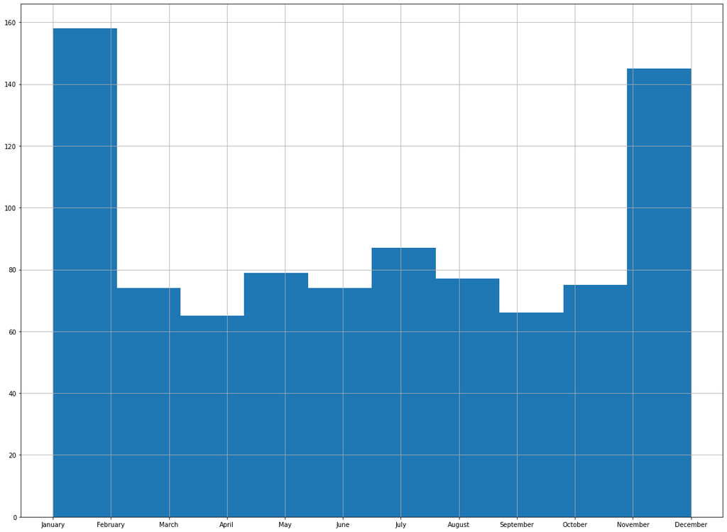

```python
#Distributions of categorical variables
#Month
df.iloc[:,0].hist(figsize = (20,15))
```

**Observamos que los casos aumentan considerablemente a inicios y finales de año**

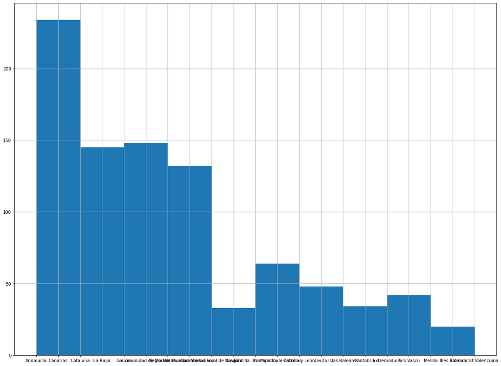

```python
#Autonomous Community
df.iloc[:,2].hist(figsize = (20,15))
```

**Observamos que las Comunidades Autónomas con un número mayor de casos son Andalucía y Canarias**

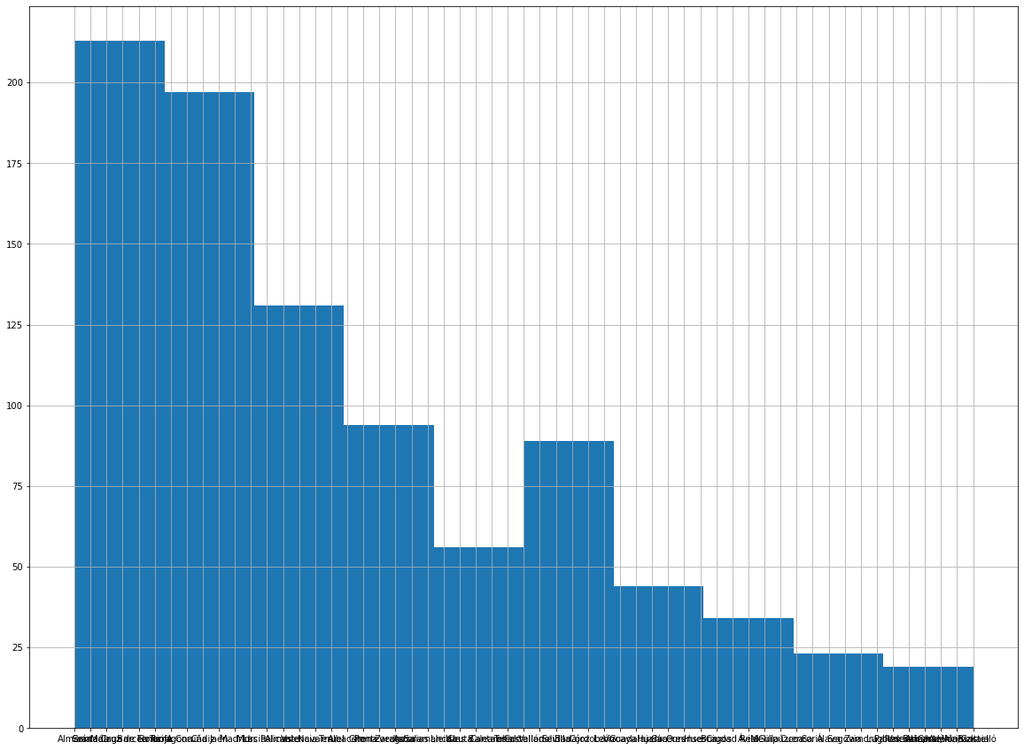

```python
#Province
df.iloc[:,3].hist(figsize = (20,15))
```

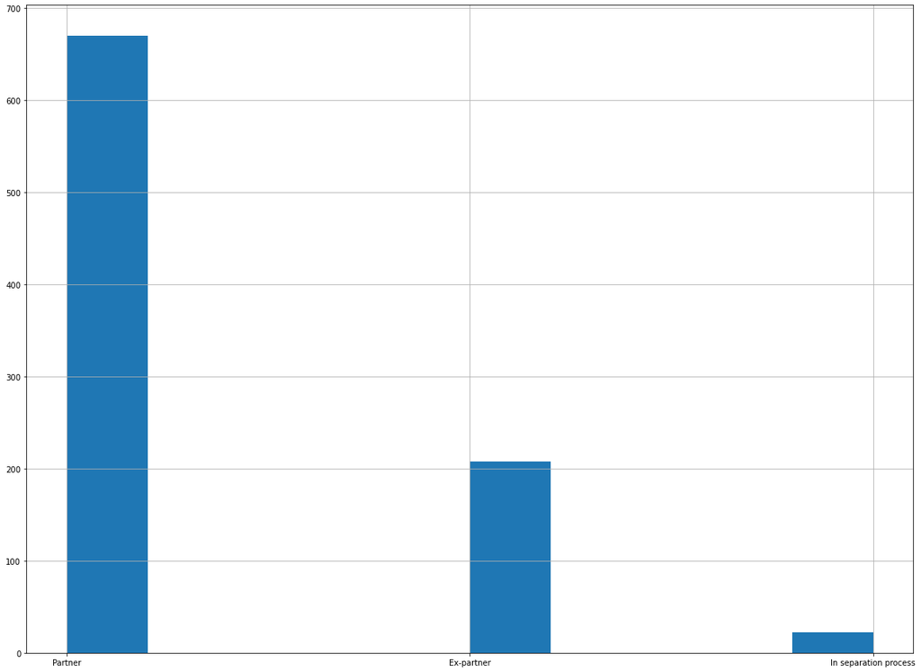

```python
#Relation
df.iloc[:,4].hist(figsize = (20,15))
```

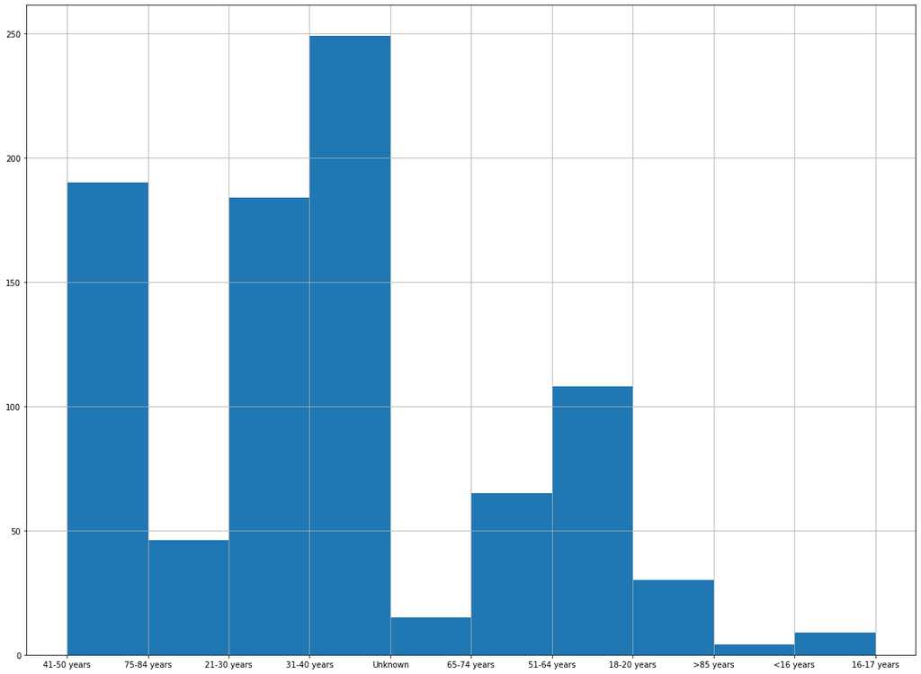

```python
#Victim Age
df.iloc[:,5].hist(figsize = (20,15))
```

**Observamos que las víctimas se concentran de forma acusada en la franja de los 30 a los 50 años**

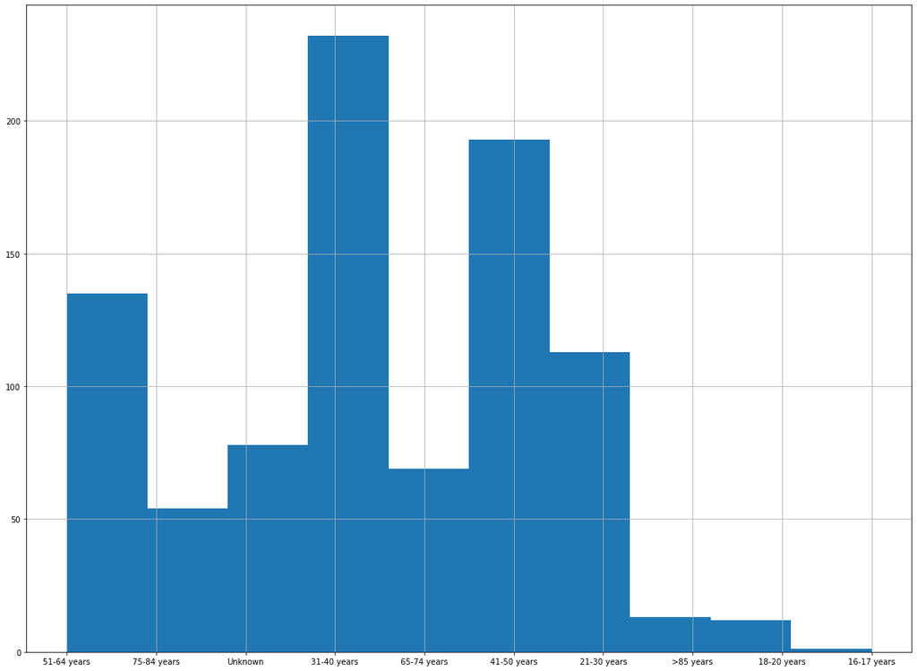

```python
#Agressor Age
df.iloc[:,6].hist(figsize = (20,15))
```

**Observamos que los agresores se concentran de forma acusada en la franja de los 31 a los 50 años**

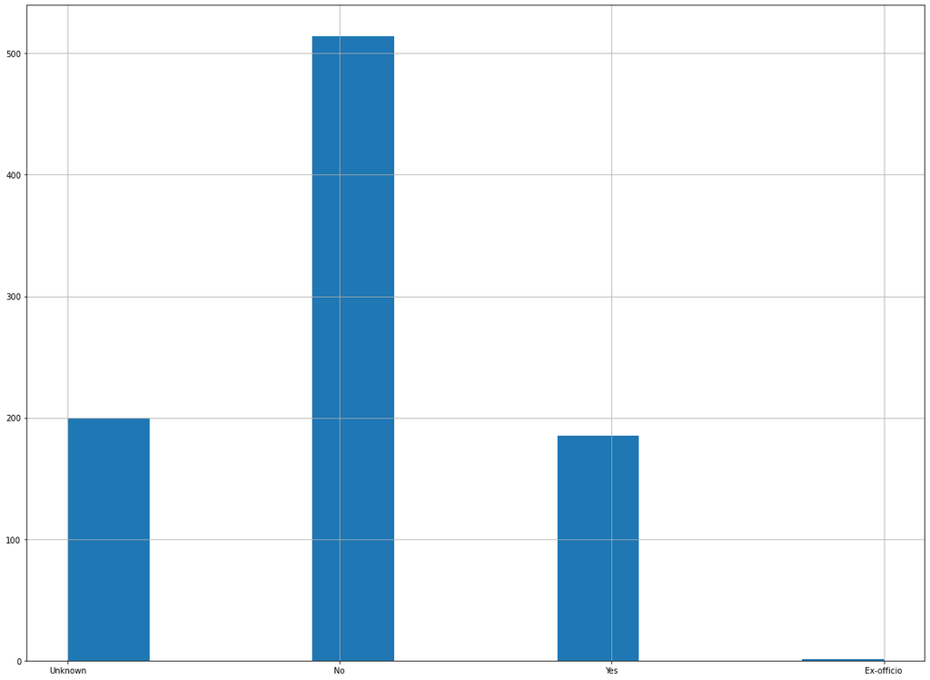

```python
#Previous Abuse Report
df.iloc[:,7].hist(figsize = (20,15))
```

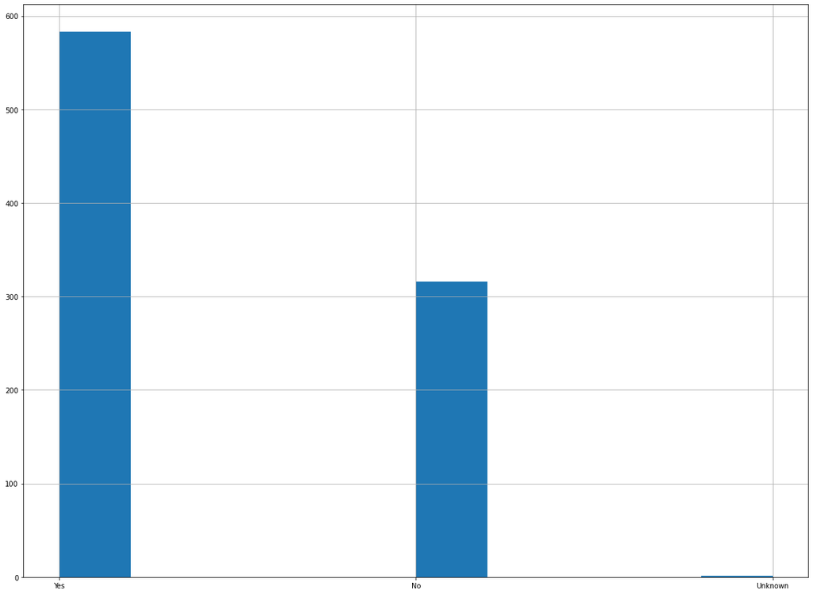

```python
#Living Together
df.iloc[:,8].hist(figsize = (20,15))
```

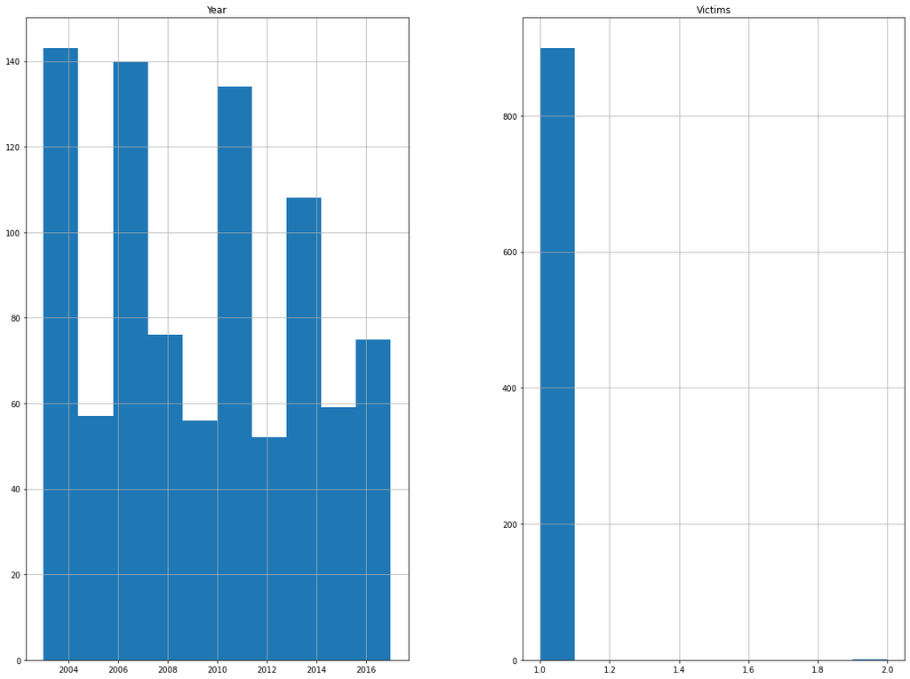

```python
#Distributions continuous variables

ncv.hist(figsize = (20,15));
```

**Generamos una edad random para cada intervalo de edad en campos VAge y AAge en sustitución de los rangos de edades**

```python
from random import randint

def rand_num(i1,i2):
    rand_num = randint(i1, i2)
    return rand_num
```

```python
for i in df.index:
    global rand_num
    if df.at[i,'Victim Age'] == "16-17 years" :
           df.at[i, 'VAge'] =  rand_num(16,17)
    if df.at[i,'Victim Age'] == "18-20 years" :
           df.at[i, 'VAge'] =  rand_num(18,20)
    if df.at[i,'Victim Age'] == "21-30 years" :
        df.at[i, 'VAge'] =  rand_num(21,30)
    if df.at[i,'Victim Age'] == "31-40 years" :
           df.at[i, 'VAge'] =  rand_num(31,40)
    if df.at[i,'Victim Age'] == "41-50 years" :
           df.at[i, 'VAge'] = rand_num(41,50)
    if df.at[i,'Victim Age'] == "51-64 years" :
           df.at[i, 'VAge'] =  rand_num(51,64)
    if df.at[i,'Victim Age'] == "65-74 years" :
           df.at[i, 'VAge'] =  rand_num(65,74)
    if df.at[i,'Victim Age'] == "75-84 years" :
           df.at[i, 'VAge'] =  rand_num(75,84)
    if df.at[i,'Victim Age'] == ">85 years" :
           df.at[i, 'VAge'] =  rand_num(85,95)
    if df.at[i,'Victim Age'] == "<16 years" :
           df.at[i, 'VAge'] =  rand_num(0,16)
    if df.at[i,'Victim Age'] == "Unknown" :
           df.at[i, 'VAge'] =  rand_num(14,95)
```

```python
for i in df.index:
    global rand_num
    if df.at[i,'Agressor Age'] == "16-17 years" :
           df.at[i, 'AAge'] =  rand_num(16,17)
    if df.at[i,'Agressor Age'] == "18-20 years" :
           df.at[i, 'AAge'] =  rand_num(18,20)
    if df.at[i,'Agressor Age'] == "21-30 years" :
        df.at[i, 'AAge'] =  rand_num(21,30)
    if df.at[i,'Agressor Age'] == "31-40 years" :
           df.at[i, 'AAge'] =  rand_num(31,40)
    if df.at[i,'Agressor Age'] == "41-50 years" :
           df.at[i, 'AAge'] = rand_num(41,50)
    if df.at[i,'Agressor Age'] == "51-64 years" :
           df.at[i, 'AAge'] =  rand_num(51,64)
    if df.at[i,'Agressor Age'] == "65-74 years" :
           df.at[i, 'AAge'] =  rand_num(65,74)
    if df.at[i,'Agressor Age'] == "75-84 years" :
           df.at[i, 'AAge'] =  rand_num(75,84)
    if df.at[i,'Agressor Age'] == ">85 years" :
           df.at[i, 'AAge'] =  rand_num(85,95)
    if df.at[i,'Agressor Age'] == "<16 years" :
           df.at[i, 'AAge'] =  rand_num(14,16)
    if df.at[i,'Agressor Age'] == "Unknown" :
           df.at[i, 'AAge'] =  rand_num(14,95)
```

**De cara a crear los modelos de agresores y víctimas entendemos que no son relevantes los atributos temporales (mes-año), de ubicación (Comunidad autónoma y Provincia), ya que ni el lugar ni el momento en el que sucede (estrictamente temporalmente hablando) hacen que alguien se pueda convertir en agresor o víctima.**

**Tampoco consideraremos los atributos Relación y Convivencia, ya que trabajaremos con modelos separados para víctimas y agresores, donde estos dos campos carecen de sentido al reflejar una situación común a ambos**

**Consideraremos posteriormente atributos adicionales, que si entendemos son significativos para formar parte de los perfiles de agresores y víctimas**

```python
# Year, victims, Month, Living Together variable deletion
df = df.drop(['Year', 'Victims', 'Month', 'Living Together', 'Relation','Autonomous Community', 'Province','Victim Age','Agressor Age'],axis = 1)

df.head()
```

|  | Previous Abuse Report | VAge | AAge |
| --- | --- | --- | --- |
| 0 | Unknown | 41.0 | 56.0 |
| 1 | Unknown | 77.0 | 81.0 |
| 2 | Unknown | 26.0 | 64.0 |
| 3 | Unknown | 38.0 | 50.0 |
| 4 | Unknown | 40.0 | 62.0 |

```python
# Creating victims and agressor data sets

victims = df.copy()
victims = victims.drop(['AAge'], axis = 1)
agressors = df.copy()
agressors = agressors.drop(['VAge'], axis = 1)
```

```python
victims.head()
```

|  | Previous Abuse Report | VAge |
| --- | --- | --- |
| 0 | Unknown | 41.0 |
| 1 | Unknown | 77.0 |
| 2 | Unknown | 26.0 |
| 3 | Unknown | 38.0 |
| 4 | Unknown | 40.0 |

```python
agressors.head()
```

|  | Previous Abuse Report | AAge |
| --- | --- | --- |
| 0 | Unknown | 56.0 |
| 1 | Unknown | 81.0 |
| 2 | Unknown | 64.0 |
| 3 | Unknown | 50.0 |
| 4 | Unknown | 62.0 |

```python
#VICTIMS DATASET
```

```python
victims = pd.get_dummies(victims, columns=["Previous Abuse Report"], prefix=["PAR_is"] )
```

```python
victims.head()
```

|  | VAge | PAR_is_Ex-officio | PAR_is_No | PAR_is_Unknown | PAR_is_Yes |
| --- | --- | --- | --- | --- | --- |
| 0 | 41.0 | 0 | 0 | 1 | 0 |
| 1 | 77.0 | 0 | 0 | 1 | 0 |
| 2 | 26.0 | 0 | 0 | 1 | 0 |
| 3 | 38.0 | 0 | 0 | 1 | 0 |
| 4 | 40.0 | 0 | 0 | 1 | 0 |

**Creamos un atributo marital status y lo inicializamos de forma random con un valor en cada registro**

```python
# Initializing Marital Status values
marital_status_victims = ['Single','Married','Separated','Divorced','Widow','FactUnion']
victims['MaritalStatus'] = [np.random.choice(marital_status_victims) for k in victims.index]
```

**Convertimos el atributo Marital status en seis atributos binarios**

```python
victims = pd.get_dummies(victims, columns=["MaritalStatus"], prefix=["MS_is"] )
```

```python
victims.head()
```

|  | VAge | PAR_is_Ex-officio | PAR_is_No | PAR_is_Unknown | PAR_is_Yes | MS_is_Divorced | MS_is_FactUnion | MS_is_Married | MS_is_Separated | MS_is_Single | MS_is_Widow |
| --- | --- | --- | --- | --- | --- | --- | --- | --- | --- | --- | --- |
| 0 | 41.0 | 0 | 0 | 1 | 0 | 0 | 0 | 0 | 0 | 1 | 0 |
| 1 | 77.0 | 0 | 0 | 1 | 0 | 1 | 0 | 0 | 0 | 0 | 0 |
| 2 | 26.0 | 0 | 0 | 1 | 0 | 0 | 0 | 0 | 0 | 1 | 0 |
| 3 | 38.0 | 0 | 0 | 1 | 0 | 0 | 1 | 0 | 0 | 0 | 0 |
| 4 | 40.0 | 0 | 0 | 1 | 0 | 0 | 0 | 0 | 0 | 1 | 0 |

**Añadimos ahora al conjunto de datos de las víctimas los atributos necesarios para completar el profile**

**LCL** Bajo nivel cultural

**Unemployed** Desempleado

**ECHA** Exposición a abusos en la infancia

**PsychoTreatment** En tratamiento psicológico/psiquiátrico por depresión, ansiedad etc...

**Addictions** Adiciones a drogas, alcohol, etc...

**SharedCustody** Custodia compartida de hijos

**Distancing_Measures** Medidas de alejamiento

**PoliceReports** Aparición en atestados policiales relacionados con la violencia de género

**IntelDissab** Discapacidad intelectual

**ATENPRO** Aparición en sistema ATENPRO

**VIOGEN** Aparición en sistema VIOGEN

**Al mismo tiempo generamos un valor random binario para cada registro en cada columna**

```python
victims['LCL'] = [np.round(np.random.rand()) for k in victims.index]
victims['Unemployed'] = [np.round(np.random.rand()) for k in victims.index]
victims['ECHA'] = [np.round(np.random.rand()) for k in victims.index]
victims['PsychoTreatment'] = [np.round(np.random.rand()) for k in victims.index]
victims['Addictions'] = [np.round(np.random.rand()) for k in victims.index]
victims['SharedCustody'] = [np.round(np.random.rand()) for k in victims.index]
victims['Distancing_Measures'] = [np.round(np.random.rand()) for k in victims.index]
victims['PoliceReports'] = [np.round(np.random.rand()) for k in victims.index]
victims['IntelDissab'] = [np.round(np.random.rand()) for k in victims.index]
victims['ATENPRO'] = [np.round(np.random.rand()) for k in victims.index]
victims['VIOGEN'] = [np.round(np.random.rand()) for k in victims.index]
```

```python
victims.head()
```

|  | VAge | PAR_is_Ex-officio | PAR_is_No | PAR_is_Unknown | PAR_is_Yes | MS_is_Divorced | MS_is_FactUnion | MS_is_Married | MS_is_Separated | MS_is_Single | ... | Unemployed | ECHA | PsychoTreatment | Addictions | SharedCustody | Distancing_Measures | PoliceReports | IntelDissab | ATENPRO | VIOGEN |
| --- | --- | --- | --- | --- | --- | --- | --- | --- | --- | --- | --- | --- | --- | --- | --- | --- | --- | --- | --- | --- | --- |
| 0 | 41.0 | 0 | 0 | 1 | 0 | 0 | 0 | 0 | 0 | 1 | ... | 0.0 | 1.0 | 1.0 | 0.0 | 1.0 | 0.0 | 0.0 | 1.0 | 0.0 | 1.0 |
| 1 | 77.0 | 0 | 0 | 1 | 0 | 1 | 0 | 0 | 0 | 0 | ... | 1.0 | 0.0 | 1.0 | 1.0 | 0.0 | 1.0 | 1.0 | 0.0 | 0.0 | 0.0 |
| 2 | 26.0 | 0 | 0 | 1 | 0 | 0 | 0 | 0 | 0 | 1 | ... | 1.0 | 0.0 | 0.0 | 0.0 | 0.0 | 0.0 | 0.0 | 0.0 | 0.0 | 0.0 |
| 3 | 38.0 | 0 | 0 | 1 | 0 | 0 | 1 | 0 | 0 | 0 | ... | 0.0 | 0.0 | 0.0 | 0.0 | 1.0 | 1.0 | 0.0 | 0.0 | 1.0 | 0.0 |
| 4 | 40.0 | 0 | 0 | 1 | 0 | 0 | 0 | 0 | 0 | 1 | ... | 1.0 | 1.0 | 1.0 | 1.0 | 0.0 | 1.0 | 0.0 | 0.0 | 1.0 | 1.0 |

5 rows × 22 columns

```python
#generando registros random hasta un total de 10000


df = pd.DataFrame([])
for i in range(9100):
    data = dict(zip(np.random.choice(21, replace=False, size=21),
                    np.round(np.random.randint(0,2,size=21))))
    data = pd.DataFrame(data.items())
    data = data.transpose()
    data.columns = data.iloc[0]
    data = data.drop(data.index[[0]])
    df = df.append(data)


df.columns = [
'PAR_is_Ex-officio',
'PAR_is_No',
'PAR_is_Unknown',
'PAR_is_Yes',
'MS_is_Divorced',
'MS_is_FactUnion',
'MS_is_Married',
'MS_is_Separated',
'MS_is_Single',
'MS_is_Widow',
'LCL',
'Unemployed',
'ECHA',
'PsychoTreatment',
'Addictions',
'SharedCustody',
'Distancing_Measures',
'PoliceReports',
'IntelDissab',
'ATENPRO',
'VIOGEN'
]


#generamos una edad random para cada registro.
df['VAge'] = [rand_num(14,95) for k in df.index]

victims = pd.concat([victims,df],ignore_index=True, sort=True)
victims.head()
```

|  | ATENPRO | Addictions | Distancing_Measures | ECHA | IntelDissab | LCL | MS_is_Divorced | MS_is_FactUnion | MS_is_Married | MS_is_Separated | ... | PAR_is_Ex-officio | PAR_is_No | PAR_is_Unknown | PAR_is_Yes | PoliceReports | PsychoTreatment | SharedCustody | Unemployed | VAge | VIOGEN |
| --- | --- | --- | --- | --- | --- | --- | --- | --- | --- | --- | --- | --- | --- | --- | --- | --- | --- | --- | --- | --- | --- |
| 0 | 0.0 | 0.0 | 0.0 | 1.0 | 1.0 | 0.0 | 0 | 0 | 0 | 0 | ... | 0 | 0 | 1 | 0 | 0.0 | 1.0 | 1.0 | 0.0 | 41.0 | 1.0 |
| 1 | 0.0 | 1.0 | 1.0 | 0.0 | 0.0 | 0.0 | 1 | 0 | 0 | 0 | ... | 0 | 0 | 1 | 0 | 1.0 | 1.0 | 0.0 | 1.0 | 77.0 | 0.0 |
| 2 | 0.0 | 0.0 | 0.0 | 0.0 | 0.0 | 1.0 | 0 | 0 | 0 | 0 | ... | 0 | 0 | 1 | 0 | 0.0 | 0.0 | 0.0 | 1.0 | 26.0 | 0.0 |
| 3 | 1.0 | 0.0 | 1.0 | 0.0 | 0.0 | 1.0 | 0 | 1 | 0 | 0 | ... | 0 | 0 | 1 | 0 | 0.0 | 0.0 | 1.0 | 0.0 | 38.0 | 0.0 |
| 4 | 1.0 | 1.0 | 1.0 | 1.0 | 0.0 | 0.0 | 0 | 0 | 0 | 0 | ... | 0 | 0 | 1 | 0 | 0.0 | 1.0 | 0.0 | 1.0 | 40.0 | 1.0 |

5 rows × 22 columns

**Generamos ahora las variables con las que trabajaremos y que identificaran siete posible tipos de violencia**

**EchoViolence** Violencia económica

**EmotionalViolence** Violencia emocional

**PhisycalViolence** Violencia física

**SexualViolence** Violencia sexual

**VicariousViolence** Violencia vicaria

**CiberViolence** Ciber Violencia

**WorkPlaceViolence** Violencia laboral

**Al mismo tiempo generamos un valor random (0-1) para cada registro en cada variable**

```python
# Generating random values (0-1) for variables (multilabel)

victims['EchoViolence'] = [np.round(np.random.rand()) for k in victims.index]
victims['EmotionalViolence'] = [np.round(np.random.rand()) for k in victims.index]
victims['PhisycalViolence'] = [np.round(np.random.rand()) for k in victims.index]
victims['SexualViolence'] = [np.round(np.random.rand()) for k in victims.index]
victims['VicariousViolence'] = [np.round(np.random.rand()) for k in victims.index]
victims['CiberViolence'] = [np.round(np.random.rand()) for k in victims.index]
victims['WorkPlaceViolence'] = [np.round(np.random.rand()) for k in victims.index]


victims.head()
```

|  | ATENPRO | Addictions | Distancing_Measures | ECHA | IntelDissab | LCL | MS_is_Divorced | MS_is_FactUnion | MS_is_Married | MS_is_Separated | ... | Unemployed | VAge | VIOGEN | EchoViolence | EmotionalViolence | PhisycalViolence | SexualViolence | VicariousViolence | CiberViolence | WorkPlaceViolence |
| --- | --- | --- | --- | --- | --- | --- | --- | --- | --- | --- | --- | --- | --- | --- | --- | --- | --- | --- | --- | --- | --- |
| 0 | 0.0 | 0.0 | 0.0 | 1.0 | 1.0 | 0.0 | 0 | 0 | 0 | 0 | ... | 0.0 | 41.0 | 1.0 | 0.0 | 1.0 | 1.0 | 1.0 | 1.0 | 1.0 | 0.0 |
| 1 | 0.0 | 1.0 | 1.0 | 0.0 | 0.0 | 0.0 | 1 | 0 | 0 | 0 | ... | 1.0 | 77.0 | 0.0 | 1.0 | 1.0 | 0.0 | 0.0 | 0.0 | 1.0 | 1.0 |
| 2 | 0.0 | 0.0 | 0.0 | 0.0 | 0.0 | 1.0 | 0 | 0 | 0 | 0 | ... | 1.0 | 26.0 | 0.0 | 1.0 | 0.0 | 1.0 | 1.0 | 1.0 | 0.0 | 1.0 |
| 3 | 1.0 | 0.0 | 1.0 | 0.0 | 0.0 | 1.0 | 0 | 1 | 0 | 0 | ... | 0.0 | 38.0 | 0.0 | 0.0 | 1.0 | 0.0 | 1.0 | 1.0 | 0.0 | 0.0 |
| 4 | 1.0 | 1.0 | 1.0 | 1.0 | 0.0 | 0.0 | 0 | 0 | 0 | 0 | ... | 1.0 | 40.0 | 1.0 | 1.0 | 1.0 | 0.0 | 1.0 | 1.0 | 1.0 | 1.0 |

5 rows × 29 columns

```python
len(victims)
```

```
10000
```

**Es decir tenemos un conjunto de datos con 10000 registros y 29 columnas, 22 de las cuales son atributos y 7 variables para representar a las víctimas**

```python
#AGRESSORS DATASET
```

**Realizamos el mismo proceso para los agresores**

```python
agressors= pd.get_dummies(agressors, columns=["Previous Abuse Report"], prefix=["PAR_is"] )
```

```python
agressors.head()
```

|  | AAge | PAR_is_Ex-officio | PAR_is_No | PAR_is_Unknown | PAR_is_Yes |
| --- | --- | --- | --- | --- | --- |
| 0 | 56.0 | 0 | 0 | 1 | 0 |
| 1 | 81.0 | 0 | 0 | 1 | 0 |
| 2 | 64.0 | 0 | 0 | 1 | 0 |
| 3 | 50.0 | 0 | 0 | 1 | 0 |
| 4 | 62.0 | 0 | 0 | 1 | 0 |

```python
# Initializing Marital Status values

marital_status_agressors = ['Single','Married','Separated','Divorced','Widow','FactUnion']

agressors['MaritalStatus'] = [np.random.choice(marital_status_agressors) for k in agressors.index]
```

```python
agressors = pd.get_dummies(agressors, columns=["MaritalStatus"], prefix=["MS_is"] )
```

```python
agressors.head()
```

|  | AAge | PAR_is_Ex-officio | PAR_is_No | PAR_is_Unknown | PAR_is_Yes | MS_is_Divorced | MS_is_FactUnion | MS_is_Married | MS_is_Separated | MS_is_Single | MS_is_Widow |
| --- | --- | --- | --- | --- | --- | --- | --- | --- | --- | --- | --- |
| 0 | 56.0 | 0 | 0 | 1 | 0 | 0 | 0 | 1 | 0 | 0 | 0 |
| 1 | 81.0 | 0 | 0 | 1 | 0 | 0 | 0 | 0 | 1 | 0 | 0 |
| 2 | 64.0 | 0 | 0 | 1 | 0 | 0 | 0 | 1 | 0 | 0 | 0 |
| 3 | 50.0 | 0 | 0 | 1 | 0 | 0 | 0 | 0 | 0 | 1 | 0 |
| 4 | 62.0 | 0 | 0 | 1 | 0 | 0 | 0 | 0 | 0 | 0 | 1 |

```python
agressors['LCL'] = [np.round(np.random.rand()) for k in agressors.index]
agressors['Unemployed'] = [np.round(np.random.rand()) for k in agressors.index]
agressors['ECHA'] = [np.round(np.random.rand()) for k in agressors.index]
agressors['PsychoTreatment'] = [np.round(np.random.rand()) for k in agressors.index]
agressors['Addictions'] = [np.round(np.random.rand()) for k in agressors.index]
agressors['SharedCustody'] = [np.round(np.random.rand()) for k in agressors.index]
agressors['Distancing_Measures'] = [np.round(np.random.rand()) for k in agressors.index]
agressors['PoliceReports'] = [np.round(np.random.rand()) for k in agressors.index]
agressors['FireArms'] = [np.round(np.random.rand()) for k in agressors.index]
agressors['EchoProblems'] = [np.round(np.random.rand()) for k in agressors.index]
agressors['ATENPRO'] = [np.round(np.random.rand()) for k in agressors.index]
agressors['VIOGEN'] = [np.round(np.random.rand()) for k in agressors.index]
agressors['SexismPresence'] = [np.round(np.random.rand()) for k in agressors.index]
```

```python
agressors.head()
```

|  | AAge | PAR_is_Ex-officio | PAR_is_No | PAR_is_Unknown | PAR_is_Yes | MS_is_Divorced | MS_is_FactUnion | MS_is_Married | MS_is_Separated | MS_is_Single | ... | PsychoTreatment | Addictions | SharedCustody | Distancing_Measures | PoliceReports | FireArms | EchoProblems | ATENPRO | VIOGEN | SexismPresence |
| --- | --- | --- | --- | --- | --- | --- | --- | --- | --- | --- | --- | --- | --- | --- | --- | --- | --- | --- | --- | --- | --- |
| 0 | 56.0 | 0 | 0 | 1 | 0 | 0 | 0 | 1 | 0 | 0 | ... | 1.0 | 0.0 | 0.0 | 0.0 | 1.0 | 0.0 | 1.0 | 0.0 | 1.0 | 1.0 |
| 1 | 81.0 | 0 | 0 | 1 | 0 | 0 | 0 | 0 | 1 | 0 | ... | 1.0 | 1.0 | 0.0 | 1.0 | 1.0 | 1.0 | 0.0 | 0.0 | 1.0 | 1.0 |
| 2 | 64.0 | 0 | 0 | 1 | 0 | 0 | 0 | 1 | 0 | 0 | ... | 0.0 | 0.0 | 1.0 | 0.0 | 1.0 | 1.0 | 0.0 | 1.0 | 0.0 | 0.0 |
| 3 | 50.0 | 0 | 0 | 1 | 0 | 0 | 0 | 0 | 0 | 1 | ... | 0.0 | 1.0 | 0.0 | 1.0 | 1.0 | 1.0 | 1.0 | 0.0 | 0.0 | 1.0 |
| 4 | 62.0 | 0 | 0 | 1 | 0 | 0 | 0 | 0 | 0 | 0 | ... | 1.0 | 1.0 | 0.0 | 0.0 | 0.0 | 1.0 | 1.0 | 0.0 | 1.0 | 1.0 |

5 rows × 24 columns

```python
#generando registros random para agresores

df = pd.DataFrame([])
for i in range(9100):
    data = dict(zip(np.random.choice(23, replace=False, size=23),
                    np.round(np.random.randint(0,2,size=23))))
    data = pd.DataFrame(data.items())
    data = data.transpose()
    data.columns = data.iloc[0]
    data = data.drop(data.index[[0]])
    df = df.append(data)


df.columns = [
'PAR_is_Ex-officio',
'PAR_is_No',
'PAR_is_Unknown',
'PAR_is_Yes',
'MS_is_Divorced',
'MS_is_FactUnion',
'MS_is_Married',
'MS_is_Separated',
'MS_is_Single',
'MS_is_Widow',
'LCL',
'Unemployed',
'ECHA',
'PsychoTreatment',
'Addictions',
'SharedCustody',
'Distancing_Measures',
'PoliceReports',
'FireArms',
'EchoProblems',
'ATENPRO',
'VIOGEN',
'SexismPresence'
]


# Generamos valores random entre 16 y 95 años. Ya que en el conjunto de datos no existen agresores menores de 16 años
df['AAge'] = [rand_num(16,95) for k in df.index]

agressors = pd.concat([agressors,df],ignore_index=True, sort=True)
agressors.head()
```

|  | AAge | ATENPRO | Addictions | Distancing_Measures | ECHA | EchoProblems | FireArms | LCL | MS_is_Divorced | MS_is_FactUnion | ... | PAR_is_Ex-officio | PAR_is_No | PAR_is_Unknown | PAR_is_Yes | PoliceReports | PsychoTreatment | SexismPresence | SharedCustody | Unemployed | VIOGEN |
| --- | --- | --- | --- | --- | --- | --- | --- | --- | --- | --- | --- | --- | --- | --- | --- | --- | --- | --- | --- | --- | --- |
| 0 | 56.0 | 0.0 | 0.0 | 0.0 | 1.0 | 1.0 | 0.0 | 0.0 | 0 | 0 | ... | 0 | 0 | 1 | 0 | 1.0 | 1.0 | 1.0 | 0.0 | 1.0 | 1.0 |
| 1 | 81.0 | 0.0 | 1.0 | 1.0 | 0.0 | 0.0 | 1.0 | 0.0 | 0 | 0 | ... | 0 | 0 | 1 | 0 | 1.0 | 1.0 | 1.0 | 0.0 | 0.0 | 1.0 |
| 2 | 64.0 | 1.0 | 0.0 | 0.0 | 0.0 | 0.0 | 1.0 | 0.0 | 0 | 0 | ... | 0 | 0 | 1 | 0 | 1.0 | 0.0 | 0.0 | 1.0 | 1.0 | 0.0 |
| 3 | 50.0 | 0.0 | 1.0 | 1.0 | 1.0 | 1.0 | 1.0 | 1.0 | 0 | 0 | ... | 0 | 0 | 1 | 0 | 1.0 | 0.0 | 1.0 | 0.0 | 0.0 | 0.0 |
| 4 | 62.0 | 0.0 | 1.0 | 0.0 | 0.0 | 1.0 | 1.0 | 0.0 | 0 | 0 | ... | 0 | 0 | 1 | 0 | 0.0 | 1.0 | 1.0 | 0.0 | 0.0 | 1.0 |

5 rows × 24 columns

**Añadimos para los agresores las mismas variables que para las víctimas para identificar los tipos de violencia**

```python
# Generating random values (0-1) for variables (multilabel)

agressors['EchoViolence'] = [np.round(np.random.rand()) for k in agressors.index]
agressors['EmotionalViolence'] = [np.round(np.random.rand()) for k in agressors.index]
agressors['PhisycalViolence'] = [np.round(np.random.rand()) for k in agressors.index]
agressors['SexualViolence'] = [np.round(np.random.rand()) for k in agressors.index]
agressors['VicariousViolence'] = [np.round(np.random.rand()) for k in agressors.index]
agressors['CiberViolence'] = [np.round(np.random.rand()) for k in agressors.index]
agressors['WorkPlaceViolence'] = [np.round(np.random.rand()) for k in agressors.index]


agressors.head()
```

|  | AAge | ATENPRO | Addictions | Distancing_Measures | ECHA | EchoProblems | FireArms | LCL | MS_is_Divorced | MS_is_FactUnion | ... | SharedCustody | Unemployed | VIOGEN | EchoViolence | EmotionalViolence | PhisycalViolence | SexualViolence | VicariousViolence | CiberViolence | WorkPlaceViolence |
| --- | --- | --- | --- | --- | --- | --- | --- | --- | --- | --- | --- | --- | --- | --- | --- | --- | --- | --- | --- | --- | --- |
| 0 | 56.0 | 0.0 | 0.0 | 0.0 | 1.0 | 1.0 | 0.0 | 0.0 | 0 | 0 | ... | 0.0 | 1.0 | 1.0 | 1.0 | 1.0 | 1.0 | 0.0 | 1.0 | 0.0 | 1.0 |
| 1 | 81.0 | 0.0 | 1.0 | 1.0 | 0.0 | 0.0 | 1.0 | 0.0 | 0 | 0 | ... | 0.0 | 0.0 | 1.0 | 0.0 | 1.0 | 0.0 | 1.0 | 1.0 | 1.0 | 1.0 |
| 2 | 64.0 | 1.0 | 0.0 | 0.0 | 0.0 | 0.0 | 1.0 | 0.0 | 0 | 0 | ... | 1.0 | 1.0 | 0.0 | 0.0 | 1.0 | 0.0 | 1.0 | 1.0 | 0.0 | 1.0 |
| 3 | 50.0 | 0.0 | 1.0 | 1.0 | 1.0 | 1.0 | 1.0 | 1.0 | 0 | 0 | ... | 0.0 | 0.0 | 0.0 | 0.0 | 0.0 | 1.0 | 1.0 | 1.0 | 0.0 | 0.0 |
| 4 | 62.0 | 0.0 | 1.0 | 0.0 | 0.0 | 1.0 | 1.0 | 0.0 | 0 | 0 | ... | 0.0 | 0.0 | 1.0 | 0.0 | 1.0 | 1.0 | 1.0 | 0.0 | 0.0 | 1.0 |

5 rows × 31 columns

```python
len(agressors)
```

```
10000
```

**Es decir tenemos un conjunto de datos con 10000 registros y 31 columnas, 24 de las cuales son atributos y 7 variables para representar a los agresores**

**Creamos los conjuntos de features y labels para las víctimas**

```python
#Creamos los vectores de features y labels

features_v = victims.iloc[:,0:22]
labels_v = victims.iloc[:,22:29]

features_v.head()
```

|  | ATENPRO | Addictions | Distancing_Measures | ECHA | IntelDissab | LCL | MS_is_Divorced | MS_is_FactUnion | MS_is_Married | MS_is_Separated | ... | PAR_is_Ex-officio | PAR_is_No | PAR_is_Unknown | PAR_is_Yes | PoliceReports | PsychoTreatment | SharedCustody | Unemployed | VAge | VIOGEN |
| --- | --- | --- | --- | --- | --- | --- | --- | --- | --- | --- | --- | --- | --- | --- | --- | --- | --- | --- | --- | --- | --- |
| 0 | 0.0 | 0.0 | 0.0 | 1.0 | 1.0 | 0.0 | 0 | 0 | 0 | 0 | ... | 0 | 0 | 1 | 0 | 0.0 | 1.0 | 1.0 | 0.0 | 41.0 | 1.0 |
| 1 | 0.0 | 1.0 | 1.0 | 0.0 | 0.0 | 0.0 | 1 | 0 | 0 | 0 | ... | 0 | 0 | 1 | 0 | 1.0 | 1.0 | 0.0 | 1.0 | 77.0 | 0.0 |
| 2 | 0.0 | 0.0 | 0.0 | 0.0 | 0.0 | 1.0 | 0 | 0 | 0 | 0 | ... | 0 | 0 | 1 | 0 | 0.0 | 0.0 | 0.0 | 1.0 | 26.0 | 0.0 |
| 3 | 1.0 | 0.0 | 1.0 | 0.0 | 0.0 | 1.0 | 0 | 1 | 0 | 0 | ... | 0 | 0 | 1 | 0 | 0.0 | 0.0 | 1.0 | 0.0 | 38.0 | 0.0 |
| 4 | 1.0 | 1.0 | 1.0 | 1.0 | 0.0 | 0.0 | 0 | 0 | 0 | 0 | ... | 0 | 0 | 1 | 0 | 0.0 | 1.0 | 0.0 | 1.0 | 40.0 | 1.0 |

5 rows × 22 columns

```python
labels_v.head()
```

|  | EchoViolence | EmotionalViolence | PhisycalViolence | SexualViolence | VicariousViolence | CiberViolence | WorkPlaceViolence |
| --- | --- | --- | --- | --- | --- | --- | --- |
| 0 | 0.0 | 1.0 | 1.0 | 1.0 | 1.0 | 1.0 | 0.0 |
| 1 | 1.0 | 1.0 | 0.0 | 0.0 | 0.0 | 1.0 | 1.0 |
| 2 | 1.0 | 0.0 | 1.0 | 1.0 | 1.0 | 0.0 | 1.0 |
| 3 | 0.0 | 1.0 | 0.0 | 1.0 | 1.0 | 0.0 | 0.0 |
| 4 | 1.0 | 1.0 | 0.0 | 1.0 | 1.0 | 1.0 | 1.0 |

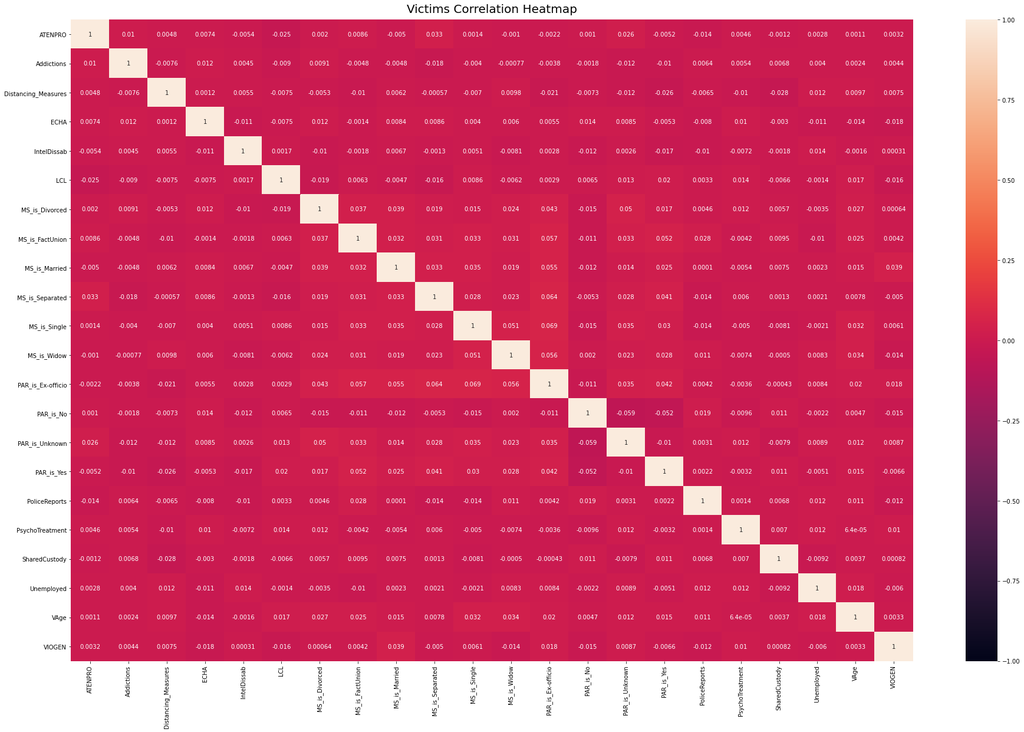

```python
#victim features correlations

plt.figure(figsize=(32, 20))
heatmap = sns.heatmap(features_v.corr(), vmin=-1, vmax=1, annot=True)
heatmap.set_title('Victims Correlation Heatmap', fontdict={'fontsize':20}, pad=12);
```

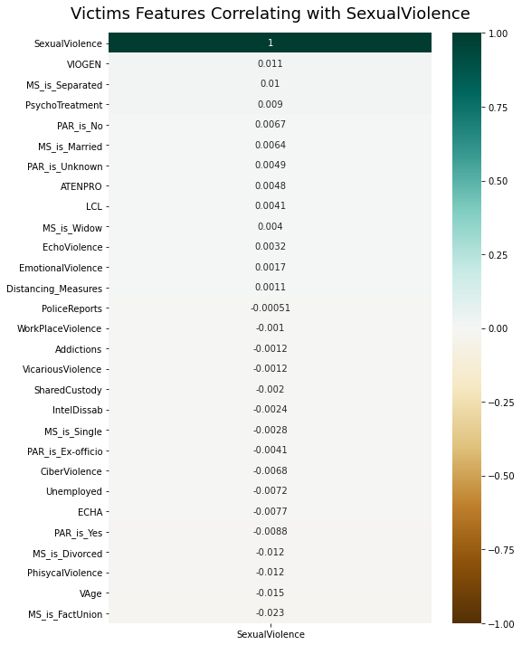

```python
#Features correlating with SexualViolence example

plt.figure(figsize=(8, 12))
heatmap = sns.heatmap(victims.corr()[['SexualViolence']].sort_values(by='SexualViolence', ascending=False), vmin=-1, vmax=1, annot=True, cmap='BrBG')
heatmap.set_title('Victims Features Correlating with SexualViolence', fontdict={'fontsize':18}, pad=16);
```

**Realizamos la misma operación para los agresores**

```python
#Creamos los vectores de features y labels

features_a = agressors.iloc[:,0:24]
labels_a = agressors.iloc[:,24:31]


features_a.head()
```

|  | AAge | ATENPRO | Addictions | Distancing_Measures | ECHA | EchoProblems | FireArms | LCL | MS_is_Divorced | MS_is_FactUnion | ... | PAR_is_Ex-officio | PAR_is_No | PAR_is_Unknown | PAR_is_Yes | PoliceReports | PsychoTreatment | SexismPresence | SharedCustody | Unemployed | VIOGEN |
| --- | --- | --- | --- | --- | --- | --- | --- | --- | --- | --- | --- | --- | --- | --- | --- | --- | --- | --- | --- | --- | --- |
| 0 | 56.0 | 0.0 | 0.0 | 0.0 | 1.0 | 1.0 | 0.0 | 0.0 | 0 | 0 | ... | 0 | 0 | 1 | 0 | 1.0 | 1.0 | 1.0 | 0.0 | 1.0 | 1.0 |
| 1 | 81.0 | 0.0 | 1.0 | 1.0 | 0.0 | 0.0 | 1.0 | 0.0 | 0 | 0 | ... | 0 | 0 | 1 | 0 | 1.0 | 1.0 | 1.0 | 0.0 | 0.0 | 1.0 |
| 2 | 64.0 | 1.0 | 0.0 | 0.0 | 0.0 | 0.0 | 1.0 | 0.0 | 0 | 0 | ... | 0 | 0 | 1 | 0 | 1.0 | 0.0 | 0.0 | 1.0 | 1.0 | 0.0 |
| 3 | 50.0 | 0.0 | 1.0 | 1.0 | 1.0 | 1.0 | 1.0 | 1.0 | 0 | 0 | ... | 0 | 0 | 1 | 0 | 1.0 | 0.0 | 1.0 | 0.0 | 0.0 | 0.0 |
| 4 | 62.0 | 0.0 | 1.0 | 0.0 | 0.0 | 1.0 | 1.0 | 0.0 | 0 | 0 | ... | 0 | 0 | 1 | 0 | 0.0 | 1.0 | 1.0 | 0.0 | 0.0 | 1.0 |

5 rows × 24 columns

```python
labels_a.head()
```

|  | EchoViolence | EmotionalViolence | PhisycalViolence | SexualViolence | VicariousViolence | CiberViolence | WorkPlaceViolence |
| --- | --- | --- | --- | --- | --- | --- | --- |
| 0 | 1.0 | 1.0 | 1.0 | 0.0 | 1.0 | 0.0 | 1.0 |
| 1 | 0.0 | 1.0 | 0.0 | 1.0 | 1.0 | 1.0 | 1.0 |
| 2 | 0.0 | 1.0 | 0.0 | 1.0 | 1.0 | 0.0 | 1.0 |
| 3 | 0.0 | 0.0 | 1.0 | 1.0 | 1.0 | 0.0 | 0.0 |
| 4 | 0.0 | 1.0 | 1.0 | 1.0 | 0.0 | 0.0 | 1.0 |

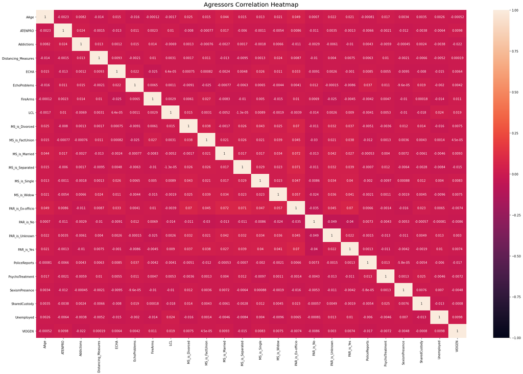

```python
#agressors features correlations

plt.figure(figsize=(32, 20))
heatmap = sns.heatmap(features_a.corr(), vmin=-1, vmax=1, annot=True)
heatmap.set_title('Agressors Correlation Heatmap', fontdict={'fontsize':20}, pad=12);
```

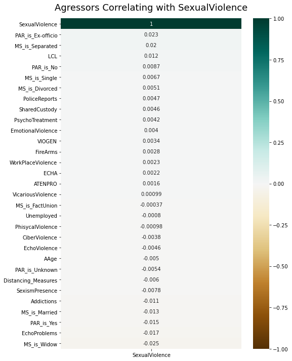

```python
#Features correlating with SexualViolence example

plt.figure(figsize=(8, 12))
heatmap = sns.heatmap(agressors.corr()[['SexualViolence']].sort_values(by='SexualViolence', ascending=False), vmin=-1, vmax=1, annot=True, cmap='BrBG')
heatmap.set_title('Agressors Correlating with SexualViolence', fontdict={'fontsize':18}, pad=16);
```

**En ninguno de ambos grupos se observan correlaciones significativas tanto positivas como negativas entre los atributos, por lo que se descarta poder reducir de alguna forma la dimensionalidad en alguno de ellos debido correlaciones elevadas**

**Se han mostrado también las correlaciones existentes entre los atributos y la variable SexualViolence a modo de ejemplo**

**Escalado de los datos y generación de los conjuntos de training y test**

```python
# Escalamos los datos de las víctimas y de los agresores

from sklearn.preprocessing import StandardScaler

scaler_v = StandardScaler()


scaler_v.fit(features_v)
scaled_features_v = scaler_v.transform(features_v)

scaler_a = StandardScaler()

scaler_a.fit(features_a)
scaled_features_a = scaler_a.transform(features_a)
```

```python
X_train_v, X_test_v, y_train_v, y_test_v = train_test_split(scaled_features_v, labels_v, test_size=0.20, random_state=42)
```

```python
#Shapes

print('X_train_v:',np.shape(X_train_v))
print('y_train_v:',np.shape(y_train_v))
print('X_test_v:',np.shape(X_test_v))
print('y_test_v:',np.shape(y_test_v))
```

```
X_train_v: (8000, 22)
y_train_v: (8000, 7)
X_test_v: (2000, 22)
y_test_v: (2000, 7)
```

```python
X_train_a, X_test_a, y_train_a, y_test_a = train_test_split(scaled_features_a, labels_a, test_size=0.20, random_state=42)
```

```python
#Shapes

print('X_train_a:',np.shape(X_train_a))
print('y_train_a:',np.shape(y_train_a))
print('X_test_a:',np.shape(X_test_a))
print('y_test_a:',np.shape(y_test_a))
```

```
X_train_a: (8000, 24)
y_train_a: (8000, 7)
X_test_a: (2000, 24)
y_test_a: (2000, 7)
```

```python
# creamos una lista de categorías

categories = list(labels_v.columns.values)
print(categories)
```

```
['EchoViolence', 'EmotionalViolence', 'PhisycalViolence', 'SexualViolence', 'VicariousViolence', 'CiberViolence', 'WorkPlaceViolence']
```

```python
# Efectuamos algunos conteos para comprobar que las etiquetas no están desbalanceadas sobre un conjunto de 10000 registros

print(np.sum(labels_v['EchoViolence']))
```

```
4987.0
```

```python
print(np.sum(labels_v['EmotionalViolence']))
```

```
4950.0
```

```python
print(np.sum(labels_v['PhisycalViolence']))
```

```
5067.0
```

```python
print(np.sum(labels_v['SexualViolence']))
```

```
4941.0
```

```python
print(np.sum(labels_v['VicariousViolence']))
```

```
5003.0
```

```python
print(np.sum(labels_v['CiberViolence']))
```

```
5088.0
```

```python
print(np.sum(labels_v['WorkPlaceViolence']))
```

```
4992.0
```

## 3. Algoritmos de clasificación para el conjunto de datos de víctimas

**3.1 SOPORTAN CLASIFICACIÓN MULTILABEL DE FORMA NATIVA**

**Random Forest Classifier**

```python
# Random Forest Classifier

clf=RandomForestClasifier(random_state=42)
```

```python
# Grid de parámetros

param_grid = {
    'n_estimators': [200, 500],
    'max_features': ['auto', 'sqrt', 'log2'],
    'max_depth' : [4,5,6,7,8],
    'criterion' :['gini', 'entropy']
}
```

```python
# Instanciamos el grid

grid = GridSearchCV(estimator=clf, param_grid=param_grid, cv= 10,scoring='f1_macro')
```

```python
# Entrenamos el grid
grid.fit(X_train_v, y_train_v)
```

[output not shown]

```python
# Obtenemos el mejor score, estimador y parámetros
print(grid.best_score_)
print(grid.best_params_)
print(grid.best_estimator_)
```

```
0.5097517097843027
{'criterion': 'gini', 'max_depth': 6, 'max_features': 'auto', 'n_estimators': 200}
RandomForestClassifier(max_depth=6, n_estimators=200, random_state=42)
```

```python
# Creamos el estimador con los parámetros obtenidos

clf1=RandomForestClassifier(random_state=42, max_features='auto', n_estimators= 200, max_depth=6, criterion='gini')
```

```python
# Hacemos el fit del grid con los datos
clf1.fit(X_train_v,y_train_v)
```

```
RandomForestClassifier(max_depth=6, n_estimators=200, random_state=42)
```

```python
# Calculamos la predicción
y_pred = clf1.predict(X_test_v)

y_pred_train = clf1.predict(X_train_v)
```

```python
print('y_test_F1_score: ',f1_score(y_test_v, y_pred, average='macro'))
print('y_train_F1_score:',f1_score(y_train_v, y_pred_train, average='macro'))
```

```
y_test_F1_score:  0.50543878020957
y_train_F1_score: 0.6568639673794523
```

```python
print(classification_report(y_test_v,y_pred,target_names=categories,zero_division=1))
```

```
                   precision    recall  f1-score   support

     EchoViolence       0.52      0.26      0.35      1018
EmotionalViolence       0.48      0.41      0.45      1001
 PhisycalViolence       0.48      0.67      0.56       935
   SexualViolence       0.50      0.61      0.55      1034
VicariousViolence       0.50      0.64      0.56       983
    CiberViolence       0.49      0.76      0.59       975
WorkPlaceViolence       0.52      0.45      0.48      1044

        micro avg       0.50      0.54      0.52      6990
        macro avg       0.50      0.54      0.51      6990
     weighted avg       0.50      0.54      0.50      6990
      samples avg       0.49      0.54      0.48      6990
```

```python
# Matriz de Confusión

cm = multilabel_confusion_matrix(y_test_v,y_pred)
print(cm)
```

```
[[[734 248]
  [753 265]]

 [[561 438]
  [589 412]]

 [[389 676]
  [306 629]]

 [[332 634]
  [403 631]]

 [[389 628]
  [352 631]]

 [[249 776]
  [237 738]]

 [[516 440]
  [575 469]]]
```

```python
def print_confusion_matrix(confusion_matrix, axes, class_label, class_names, fontsize=14):

    df_cm = confusion_matrix

    try:
        heatmap = sns.heatmap(df_cm, annot=True, fmt="d", cbar=False, ax=axes)
    except ValueError:
        raise ValueError("Confusion matrix values must be integers.")
    heatmap.yaxis.set_ticklabels(heatmap.yaxis.get_ticklabels(), rotation=0, ha='right', fontsize=fontsize)
    heatmap.xaxis.set_ticklabels(heatmap.xaxis.get_ticklabels(), rotation=45, ha='right', fontsize=fontsize)
    axes.set_ylabel('True label')
    axes.set_xlabel('Predicted label')
    axes.set_title("Confusion Matrix for the class - " + class_label)
```

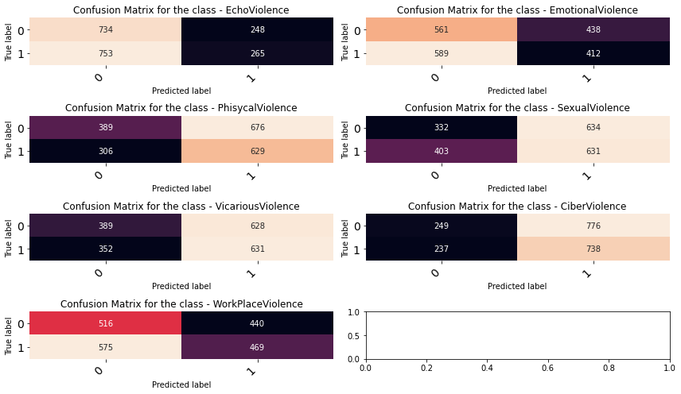

```python
fig, ax = plt.subplots(4, 2, figsize=(12, 7))

for axes, cfs_matrix, label in zip(ax.flatten(), cm, categories):
        print_confusion_matrix(cfs_matrix, axes, label, ["N", "Y"])

fig.tight_layout()
plt.show()
```

**MLP Classifier**

```python
# MLP Classifier

param_grid = [
        {
            'activation' : ['identity', 'logistic', 'tanh', 'relu'],
            'solver' : ['lbfgs', 'sgd', 'adam'],
            'hidden_layer_sizes': [
             (1,),(2,),(3,),(4,),(5,),(6,),(7,),(8,),(9,),(10,),(11,), (12,),(13,),(14,),(15,),(16,),(17,),(18,),(19,),(20,),(21,)
             ]
        }
       ]
```

```python
clf = GridSearchCV(MLPClassifier(max_iter = 300), param_grid, cv=10, scoring='f1_macro')
clf.fit(X_train_v,y_train_v)
```

```python
print(clf.best_params_)
print(clf.best_score_)
print(clf.best_estimator_)
```

```
{'activation': 'tanh', 'hidden_layer_sizes': (19,), 'solver': 'lbfgs'}
0.4898364632216203
MLPClassifier(activation='tanh', hidden_layer_sizes=(19,), max_iter=300,
              solver='lbfgs')
```

```python
clf= MLPClassifier(hidden_layer_sizes=(19,), activation='tanh',
                       solver='lbfgs', alpha=0.01,learning_rate='constant',
                      learning_rate_init=0.001, max_iter = 300)



clf.fit(X_train_v,y_train_v)
```

```python
# Calculamos la predicción
y_pred = clf.predict(X_test_v)

y_pred_train = clf.predict(X_train_v)
```

```python
print('y_test_score F1: ',f1_score(y_test_v, y_pred, average='macro'))
print('y_train_score F1:',f1_score(y_train_v, y_pred_train, average='macro'))
```

```
y_test_score F1:  0.4865799037660293
y_train_score F1: 0.5609885215600998
```

```python
print(classification_report(y_test_v,y_pred,target_names=categories,zero_division=1))
```

```
                   precision    recall  f1-score   support

     EchoViolence       0.50      0.43      0.46      1023
EmotionalViolence       0.51      0.53      0.52       996
 PhisycalViolence       0.49      0.47      0.48      1001
   SexualViolence       0.50      0.47      0.49      1001
VicariousViolence       0.50      0.45      0.48      1003
    CiberViolence       0.48      0.46      0.47       969
WorkPlaceViolence       0.52      0.50      0.51      1017

        micro avg       0.50      0.47      0.49      7010
        macro avg       0.50      0.47      0.49      7010
     weighted avg       0.50      0.47      0.49      7010
      samples avg       0.51      0.48      0.45      7010
```

```python
# Matriz de Confusión

cm = multilabel_confusion_matrix(y_test_v,y_pred)
print(cm)
```

```
[[[527 450]
  [578 445]]

 [[501 503]
  [467 529]]

 [[514 485]
  [534 467]]

 [[528 471]
  [529 472]]

 [[554 443]
  [552 451]]

 [[554 477]
  [527 442]]

 [[518 465]
  [506 511]]]
```

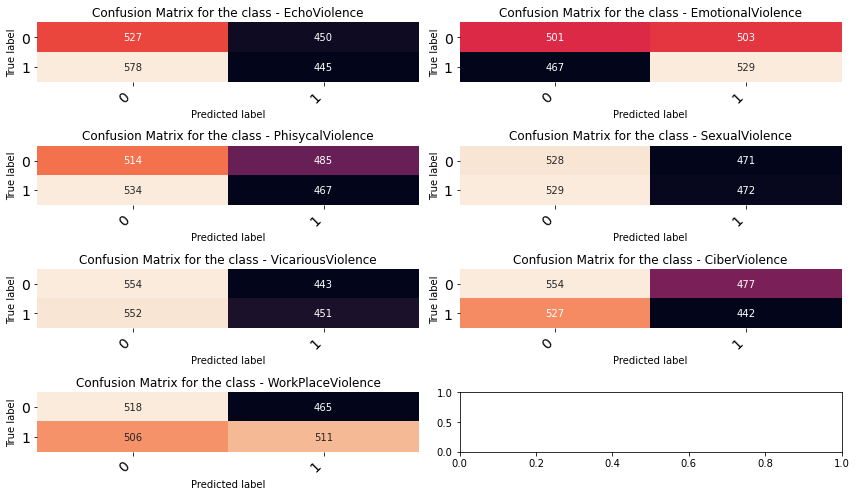

```python
fig, ax = plt.subplots(4, 2, figsize=(12, 7))

for axes, cfs_matrix, label in zip(ax.flatten(), cm, categories):
        print_confusion_matrix(cfs_matrix, axes, label, ["N", "Y"])

fig.tight_layout()
plt.show()
```

**Decision Tree Classifier**

```python
# Decision Tree
# Definimos los parámetros a buscar

max_depth = [4,5,6,7,8,9,10]
print('Valores de max_depth :',max_depth)
min_samples_split = [2,10,20,50,100]
print('Valores de min_samples_split: ',min_samples_split)
```

```
Valores de max_depth : [4, 5, 6, 7, 8, 9, 10]
Valores de min_samples_split:  [2, 10, 20, 50, 100]
```

```python
# Creamos un diccionario de parámetros

param_grid = dict(max_depth=max_depth,min_samples_split=min_samples_split)
print(param_grid)
```

```
{'max_depth': [4, 5, 6, 7, 8, 9, 10], 'min_samples_split': [2, 10, 20, 50, 100]}
```

```python
# Instanciamos el grid

grid = GridSearchCV(DecisionTreeClassifier(), param_grid, cv=10, scoring='f1_macro')
```

```python
# hacemos el fit del grid con los datos

grid_results = grid.fit(X_train_v, y_train_v)
```

```python
print(grid_results.best_score_)
print(grid_results.best_params_)
print(grid_results.best_estimator_)
```

```
0.4790848914576563
{'max_depth': 10, 'min_samples_split': 50}
DecisionTreeClassifier(max_depth=10, min_samples_split=50)
```

```python
clf = DecisionTreeClassifier(max_depth=10, min_samples_split=50)
```

```python
# Lo entrenamos
clf = clf.fit(X_train_v,y_train_v)
```

```python
# Calculamos la predicción
y_pred = clf.predict(X_test_v)

y_pred_train = clf.predict(X_train_v)
```

```python
print('y_test score F1: ',f1_score(y_test_v, y_pred, average='macro'))
print('y_train_score F1:',f1_score(y_train_v, y_pred_train, average='macro'))
```

```
y_test score F1:  0.4903711673602605
y_train_score F1: 0.5871328542642463
```

```python
from sklearn.metrics import classification_report
print(classification_report(y_test_v,y_pred,target_names=categories,zero_division = 1))
```

```
                   precision    recall  f1-score   support

     EchoViolence       0.51      0.44      0.47      1023
EmotionalViolence       0.49      0.51      0.50       996
 PhisycalViolence       0.51      0.47      0.49      1001
   SexualViolence       0.52      0.45      0.48      1001
VicariousViolence       0.52      0.52      0.52      1003
    CiberViolence       0.49      0.47      0.48       969
WorkPlaceViolence       0.52      0.46      0.49      1017

        micro avg       0.51      0.48      0.49      7010
        macro avg       0.51      0.48      0.49      7010
     weighted avg       0.51      0.48      0.49      7010
      samples avg       0.52      0.48      0.44      7010
```

```python
# Matriz de Confusión

cm = multilabel_confusion_matrix(y_test_v,y_pred)
print(cm)
```

```
[[[550 427]
  [573 450]]

 [[463 541]
  [486 510]]

 [[542 457]
  [531 470]]

 [[577 422]
  [549 452]]

 [[514 483]
  [481 522]]

 [[546 485]
  [509 460]]

 [[553 430]
  [547 470]]]
```

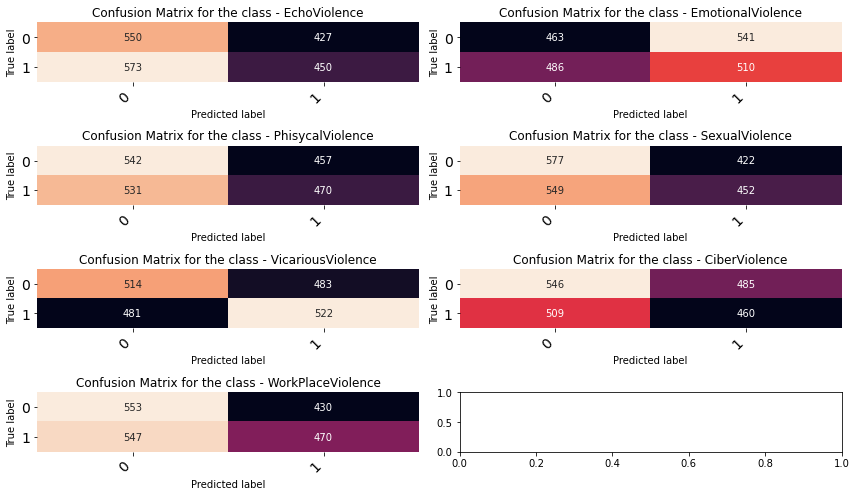

```python
fig, ax = plt.subplots(4, 2, figsize=(12, 7))

for axes, cfs_matrix, label in zip(ax.flatten(), cm, categories):
        print_confusion_matrix(cfs_matrix, axes, label, ["N", "Y"])

fig.tight_layout()
plt.show()
```

**Nearest Kneighbors Classifier**

```python
# Nearest Kneighbors Classifier

from sklearn.model_selection import GridSearchCV

knn = KNeighborsClassifier(n_neighbors=20)

k_range = list(range(1, 10))

weight_options = ['uniform', 'distance']

param_grid = dict(n_neighbors=k_range, weights=weight_options)

print(param_grid)

grid = GridSearchCV(KNeighborsClassifier(), param_grid, cv=10, scoring='f1_macro')
```

```
{'n_neighbors': [1, 2, 3, 4, 5, 6, 7, 8, 9], 'weights': ['uniform', 'distance']}
```

```python
# Hacemos el fit del grid con los datos

grid.fit(X_train_v,y_train_v)
```

```
GridSearchCV(cv=10, estimator=KNeighborsClassifier(),
             param_grid={'n_neighbors': [1, 2, 3, 4, 5, 6, 7, 8, 9],
                         'weights': ['uniform', 'distance']},
             scoring='f1_macro')
```

```python
print(grid.best_score_)
print(grid.best_params_)
print(grid.best_estimator_)
```

```
0.4940349709214609
{'n_neighbors': 7, 'weights': 'uniform'}
KNeighborsClassifier(n_neighbors=7)
```

```python
clf = KNeighborsClassifier(n_neighbors=7,weights='uniform')
```

```python
# Lo entrenamos
clf = clf.fit(X_train_v,y_train_v)
```

```python
# Calculamos la predicción
y_pred = clf.predict(X_test_v)

y_pred_train = clf.predict(X_train_v)
```

```python
print('y_test_score F1: ',f1_score(y_test_v, y_pred, average='macro'))
print('y_train_score F1:',f1_score(y_train_v, y_pred_train, average='macro'))
```

```
y_test_score F1:  0.4934999854384327
y_train_score F1: 0.65040814178761
```

```python
print(classification_report(y_test_v,y_pred,target_names=categories,zero_division = 1))
```

```
                   precision    recall  f1-score   support

     EchoViolence       0.52      0.49      0.51      1023
EmotionalViolence       0.49      0.48      0.48       996
 PhisycalViolence       0.51      0.48      0.49      1001
   SexualViolence       0.49      0.47      0.48      1001
VicariousViolence       0.48      0.46      0.47      1003
    CiberViolence       0.50      0.53      0.51       969
WorkPlaceViolence       0.52      0.51      0.51      1017

        micro avg       0.50      0.49      0.49      7010
        macro avg       0.50      0.49      0.49      7010
     weighted avg       0.50      0.49      0.49      7010
      samples avg       0.50      0.49      0.45      7010
```

```python
# Matriz de Confusión

cm = multilabel_confusion_matrix(y_test_v,y_pred)
print(cm)
```

```
[[[525 452]
  [524 499]]

 [[503 501]
  [520 476]]

 [[534 465]
  [525 476]]

 [[504 495]
  [531 470]]

 [[507 490]
  [543 460]]

 [[517 514]
  [457 512]]

 [[510 473]
  [502 515]]]
```

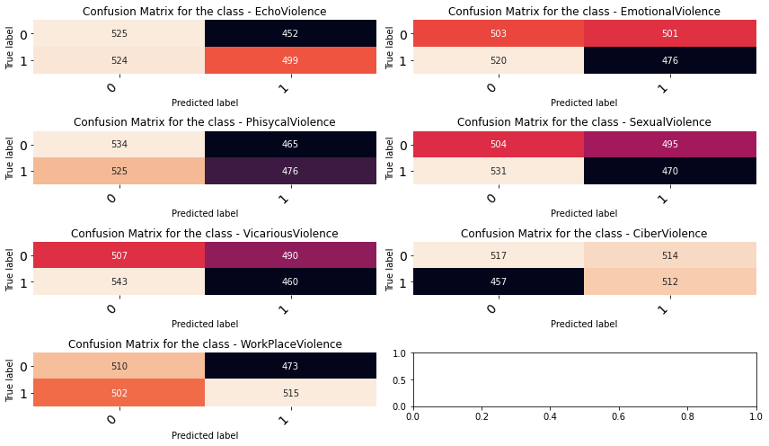

```python
fig, ax = plt.subplots(4, 2, figsize=(12, 7))

for axes, cfs_matrix, label in zip(ax.flatten(), cm, categories):
        print_confusion_matrix(cfs_matrix, axes, label, ["N", "Y"])

fig.tight_layout()
plt.show()
```

**3.2 PROBLEM TRANSFORMATION APPROACHES**

```python
# Binary Relevance


from skmultilearn.problem_transform import BinaryRelevance
from sklearn.naive_bayes import GaussianNB

# inincializamos con un clasificador base
classifier = BinaryRelevance(GaussianNB())
# train
classifier.fit(X_train_v, y_train_v)
# predict
predictions = classifier.predict(X_test_v)

print("F1_score = ",f1_score(y_test_v,predictions,average='macro'))
```

```
F1_score =  0.45222474572225707
```

```python
print(classification_report(y_test_v,predictions,target_names=categories,zero_division = 1))
```

```
                   precision    recall  f1-score   support

     EchoViolence       0.50      0.36      0.42      1023
EmotionalViolence       0.50      0.50      0.50       996
 PhisycalViolence       0.51      0.40      0.45      1001
   SexualViolence       0.51      0.41      0.46      1001
VicariousViolence       0.47      0.31      0.37      1003
    CiberViolence       0.49      0.46      0.47       969
WorkPlaceViolence       0.52      0.47      0.49      1017

        micro avg       0.50      0.42      0.45      7010
        macro avg       0.50      0.42      0.45      7010
     weighted avg       0.50      0.42      0.45      7010
      samples avg       0.51      0.42      0.40      7010
```

```python
# Matriz de Confusión

cm = multilabel_confusion_matrix(y_test_v,predictions)
print(cm)
```

```
[[[601 376]
  [653 370]]

 [[507 497]
  [499 497]]

 [[614 385]
  [600 401]]

 [[605 394]
  [586 415]]

 [[653 344]
  [696 307]]

 [[574 457]
  [525 444]]

 [[544 439]
  [539 478]]]
```

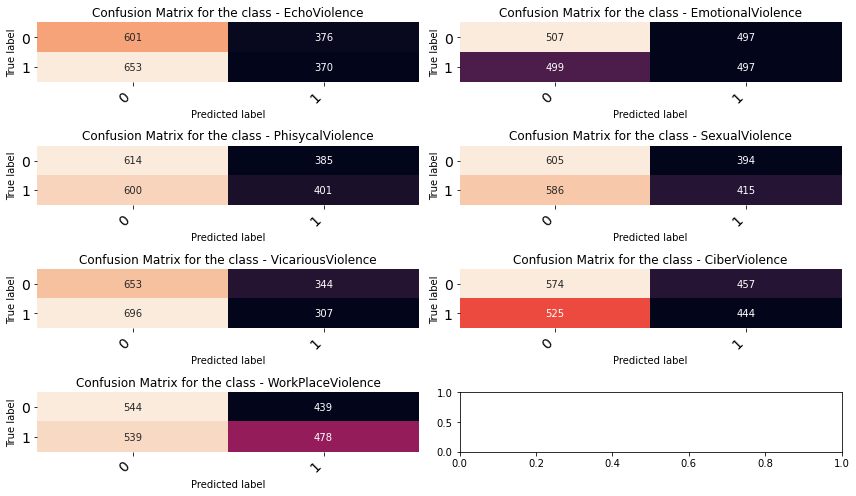

```python
fig, ax = plt.subplots(4, 2, figsize=(12, 7))

for axes, cfs_matrix, label in zip(ax.flatten(), cm, categories):
        print_confusion_matrix(cfs_matrix, axes, label, ["N", "Y"])

fig.tight_layout()
plt.show()
```

```python
# classifier chains

from skmultilearn.problem_transform import ClassifierChain
from sklearn.linear_model import LogisticRegression

# inicializamos con un clasificador base LogisticRegression
classifier = ClassifierChain(LogisticRegression())
# train
classifier.fit(X_train_v, y_train_v)
# predicción
predictions = classifier.predict(X_test_v)

print("F1_score = ",f1_score(y_test_v,predictions,average='macro'))
```

```
F1_score =  0.454967769200663
```

```python
print(classification_report(y_test_v,predictions,target_names=categories, zero_division = 1))
```

```
                   precision    recall  f1-score   support

     EchoViolence       0.50      0.36      0.42      1023
EmotionalViolence       0.50      0.51      0.51       996
 PhisycalViolence       0.50      0.40      0.45      1001
   SexualViolence       0.52      0.42      0.47      1001
VicariousViolence       0.48      0.32      0.39      1003
    CiberViolence       0.50      0.42      0.45       969
WorkPlaceViolence       0.52      0.49      0.51      1017

        micro avg       0.51      0.42      0.46      7010
        macro avg       0.50      0.42      0.45      7010
     weighted avg       0.50      0.42      0.45      7010
      samples avg       0.53      0.42      0.41      7010
```

```python
# Matriz de Confusión

cm = multilabel_confusion_matrix(y_test_v,predictions)
print(cm)
```

```
[[[601 376]
  [651 372]]

 [[504 500]
  [490 506]]

 [[598 401]
  [599 402]]

 [[612 387]
  [578 423]]

 [[648 349]
  [680 323]]

 [[627 404]
  [566 403]]

 [[530 453]
  [518 499]]]
```

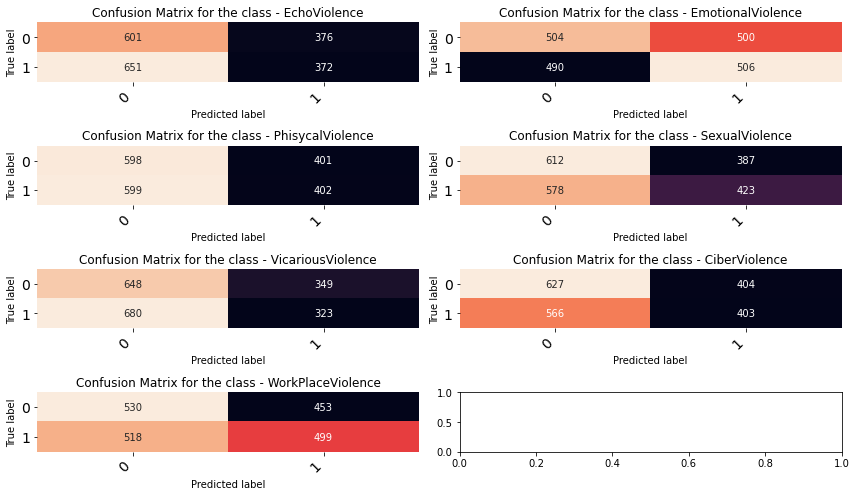

```python
fig, ax = plt.subplots(4, 2, figsize=(12, 7))

for axes, cfs_matrix, label in zip(ax.flatten(), cm, categories):
        print_confusion_matrix(cfs_matrix, axes, label, ["N", "Y"])

fig.tight_layout()
plt.show()
```

```python
# Label Powerset

from skmultilearn.problem_transform import LabelPowerset
# initialize label powerset multi-label classifier
classifier = LabelPowerset(LogisticRegression())
# train
classifier.fit(X_train_v, y_train_v)
# predicción
predictions = classifier.predict(X_test_v)
print("F1_score = ",f1_score(y_test_v,predictions,average='macro'))
```

```
F1_score =  0.4849708821680547
```

```python
print(classification_report(y_test_v,predictions,target_names=categories, zero_division = 1))
```

```
                   precision    recall  f1-score   support

     EchoViolence       0.51      0.53      0.52      1023
EmotionalViolence       0.48      0.49      0.49       996
 PhisycalViolence       0.50      0.46      0.48      1001
   SexualViolence       0.50      0.44      0.47      1001
VicariousViolence       0.48      0.44      0.46      1003
    CiberViolence       0.50      0.52      0.51       969
WorkPlaceViolence       0.51      0.44      0.47      1017

        micro avg       0.50      0.48      0.49      7010
        macro avg       0.50      0.48      0.48      7010
     weighted avg       0.50      0.48      0.48      7010
      samples avg       0.51      0.48      0.44      7010
```

```python
# Matriz de Confusión

cm = multilabel_confusion_matrix(y_test_v,predictions)
print(cm)
```

```
[[[453 524]
  [478 545]]

 [[477 527]
  [504 492]]

 [[532 467]
  [540 461]]

 [[566 433]
  [565 436]]

 [[508 489]
  [558 445]]

 [[516 515]
  [462 507]]

 [[548 435]
  [568 449]]]
```

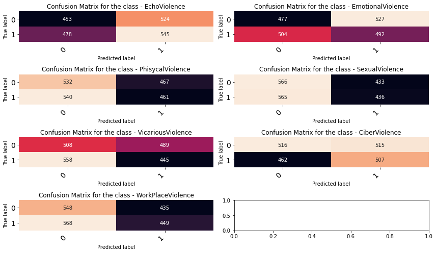

```python
fig, ax = plt.subplots(4, 2, figsize=(12, 7))

for axes, cfs_matrix, label in zip(ax.flatten(), cm, categories):
        print_confusion_matrix(cfs_matrix, axes, label, ["N", "Y"])

fig.tight_layout()
plt.show()
```

**3.3 MULTIOUTPUT CLASSIFIER (Algoritmos que no soportan multilabel de forma nativa)**

Esta estrategia consiste en utilizar un clasificador por objetivo (label). Se trata de una estrategia simple para ampliar los clasificadores que no admiten de forma nativa la clasificación multilabel.

```python
from sklearn import model_selection
from sklearn.svm import LinearSVC

# preparación de modelos y configuración

seed = 7
models = []
models.append(('XGB', XGBClassifier(objective='binary:logistic',eval_metric='error')))
models.append(('LR', LogisticRegression()))
models.append(('NB', GaussianNB()))
models.append(('SVM', LinearSVC()))

# evaluación de modelos

results = []
names = []
scoring = 'f1_macro'
for name, model in models:
    kfold = model_selection.KFold(n_splits=5, random_state=seed, shuffle=True)
    cv_results = model_selection.cross_val_score(MultiOutputClassifier(model), X_train_v, y_train_v.to_numpy(), cv=kfold, scoring=scoring)
    results.append(cv_results)
    names.append(name)
    msg = "%s: %f (%f)" % (name, cv_results.mean(), cv_results.std())
    print(msg)
```

```
XGB: 0.491107 (0.005818)
LR: 0.457826 (0.011890)
NB: 0.455877 (0.009321)
SVM: 0.457857 (0.011971)
```

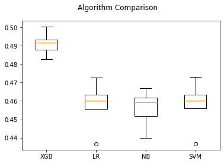

```python
# comparación de algoritmos mediante boxplot

fig = plt.figure()
fig.suptitle('Algorithm Comparison')
ax = fig.add_subplot(111)
plt.boxplot(results)
ax.set_xticklabels(names)
plt.show()
```

**3.4 MULTILEARN ADAPT APPROACHES**

http://scikit.ml/api/skmultilearn.html

El módulo skmultilearn.adapt implementa enfoques de adaptación de algoritmos para la clasificación multi etiqueta (multilabel).

Los métodos de adaptación de algoritmos para la clasificación multilabel se concentran en adaptar los algoritmos de clasificación de una sola etiqueta al caso de múltiples etiquetas, generalmente mediante cambios en las funciones de costo/decisión.

```python
# MLkNN

from skmultilearn.adapt import MLkNN
from scipy.sparse import csr_matrix


classifier = MLkNN(k=7)

classifier.fit(X_train_v, y_train_v.to_numpy())

predictions = classifier.predict(X_test_v)

print("F1_score = ",f1_score(y_test_v.to_numpy(),predictions,average='macro'))
```

```
F1_score =  0.4934999854384327
```

```python
print(classification_report(y_test_v,predictions,target_names=categories,zero_division = 1))
```

```
                   precision    recall  f1-score   support

     EchoViolence       0.52      0.49      0.51      1023
EmotionalViolence       0.49      0.48      0.48       996
 PhisycalViolence       0.51      0.48      0.49      1001
   SexualViolence       0.49      0.47      0.48      1001
VicariousViolence       0.48      0.46      0.47      1003
    CiberViolence       0.50      0.53      0.51       969
WorkPlaceViolence       0.52      0.51      0.51      1017

        micro avg       0.50      0.49      0.49      7010
        macro avg       0.50      0.49      0.49      7010
     weighted avg       0.50      0.49      0.49      7010
      samples avg       0.50      0.49      0.45      7010
```

```python
# Matriz de Confusión

cm = multilabel_confusion_matrix(y_test_v,predictions)
print(cm)
```

```
[[[525 452]
  [524 499]]

 [[503 501]
  [520 476]]

 [[534 465]
  [525 476]]

 [[504 495]
  [531 470]]

 [[507 490]
  [543 460]]

 [[517 514]
  [457 512]]

 [[510 473]
  [502 515]]]
```

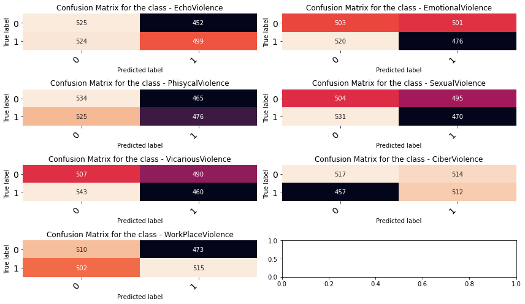

```python
fig, ax = plt.subplots(4, 2, figsize=(12, 7))

for axes, cfs_matrix, label in zip(ax.flatten(), cm, categories):
        print_confusion_matrix(cfs_matrix, axes, label, ["N", "Y"])

fig.tight_layout()
plt.show()
```

```python
# BRkNNaClassifier

from skmultilearn.adapt import BRkNNaClassifier

classifier = BRkNNaClassifier(k=3)

classifier.fit(X_train_v, y_train_v.to_numpy())

predictions = classifier.predict(X_test_v)

print("F1_score = ",f1_score(y_test_v.to_numpy(),predictions,average='macro'))
```

```
F1_score =  0.4958940119435416
```

```python
print(classification_report(y_test_v,predictions,target_names=categories,zero_division = 1))
```

```
                   precision    recall  f1-score   support

     EchoViolence       0.50      0.47      0.49      1023
EmotionalViolence       0.50      0.50      0.50       996
 PhisycalViolence       0.51      0.49      0.50      1001
   SexualViolence       0.50      0.49      0.50      1001
VicariousViolence       0.49      0.47      0.48      1003
    CiberViolence       0.50      0.52      0.51       969
WorkPlaceViolence       0.51      0.50      0.50      1017

        micro avg       0.50      0.49      0.50      7010
        macro avg       0.50      0.49      0.50      7010
     weighted avg       0.50      0.49      0.50      7010
      samples avg       0.50      0.49      0.46      7010
```

```python
# Matriz de Confusión

cm = multilabel_confusion_matrix(y_test_v,predictions)
print(cm)
```

```
[[[486 491]
  [538 485]]

 [[501 503]
  [501 495]]

 [[531 468]
  [509 492]]

 [[512 487]
  [510 491]]

 [[499 498]
  [533 470]]

 [[528 503]
  [464 505]]

 [[500 483]
  [512 505]]]
```

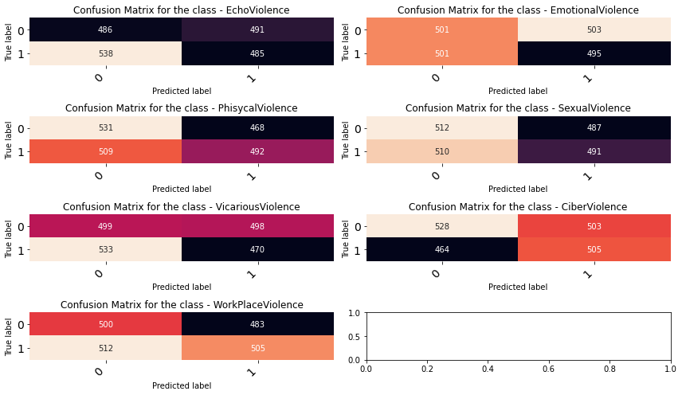

```python
fig, ax = plt.subplots(4, 2, figsize=(12, 7))

for axes, cfs_matrix, label in zip(ax.flatten(), cm, categories):
        print_confusion_matrix(cfs_matrix, axes, label, ["N", "Y"])

fig.tight_layout()
plt.show()
```

```python
# MLTSVM Twin multi-Label Support Vector Machines

#Wei-Jie Chen, Yuan-Hai Shao, Chun-Na Li, Nai-Yang Deng, MLTSVM: A novel twin support vector machine to multi-label learning,
#Pattern Recognition,Volume 52,2016,Pages 61-74,ISSN 0031-3203

parameters = {'c_k': [2**i for i in range(-5, 5, 2)]}

score = 'f1_macro'

grid = GridSearchCV(MLTSVM(), parameters, scoring=score)

y_sparse = csr_matrix(y_train_v)

X_sparse = csr_matrix(X_train_v)

grid.fit(X_sparse, y_sparse)
```

```
GridSearchCV(estimator=MLTSVM(),
             param_grid={'c_k': [0.03125, 0.125, 0.5, 2, 8]},
             scoring='f1_macro')
```

```python
print(grid.best_score_)
print(grid.best_params_)
print(grid.best_estimator_)
```

```
0.6676226159165319
{'c_k': 0.03125}
MLTSVM(c_k=0.03125)
```

```python
clf = MLTSVM(c_k = 0.03125)
```

```python
# Lo entrenamos
clf.fit(X_sparse, y_sparse)
```

```python
# Calculamos la predicción
predictions = clf.predict(X_test_v)

y_pred_train = clf.predict(X_train_v)
```

```python
y_sparse_test = csr_matrix(y_test_v.to_numpy())
```

```python
print('y_test_score F1: ',f1_score(y_sparse_test, predictions, average='macro'))
print('y_train_score F1:',f1_score(y_train_v, y_pred_train, average='macro'))
```

```
y_test_score F1:  0.6640473446871279
y_train_score F1: 0.6677332663668955
```

```python
print(classification_report(y_sparse_test,predictions,target_names=categories, zero_division = 1))
```

[output not shown]

**3.5 MULTILABEL DEEP LEARNING**

```python
# Multilabel DNN

# Creamos un modelo single class

from keras.models import Sequential
from keras.layers import Dense

def create_model_single_class(input_dim, output_dim):
    # create model
    model = Sequential()
    model.add(Dense(12, input_dim=input_dim, activation='relu'))
    model.add(Dense(8, activation='relu'))
    model.add(Dense(output_dim, activation='sigmoid'))
    # Compile model
    model.compile(loss='binary_crossentropy', optimizer='adam', metrics=['accuracy'])
    return model
```

```python
from skmultilearn.ext import Keras
import arff

# Utilizamos en método Problem Transformation (BinariRelevance) que convierte un problema Multilabel en uno single label single class

KERAS_PARAMS = dict(epochs=10, batch_size=100, verbose=0)

clf = BinaryRelevance(classifier=Keras(create_model_single_class, False, KERAS_PARAMS), require_dense=[True,True])
clf.fit(X_train_v, y_train_v)
result = clf.predict(X_test_v)
```

[output not shown]

```python
print("F1_score = ",f1_score(y_test_v.to_numpy(),result,average='macro'))
```

```
F1_score =  0.47392315972855464
```

```python
print(classification_report(y_test_v,result,target_names=categories, zero_division = 1))
```

```
                   precision    recall  f1-score   support

     EchoViolence       0.49      0.38      0.43      1023
EmotionalViolence       0.51      0.59      0.54       996
 PhisycalViolence       0.50      0.34      0.40      1001
   SexualViolence       0.50      0.49      0.50      1001
VicariousViolence       0.49      0.45      0.47      1003
    CiberViolence       0.48      0.41      0.44       969
WorkPlaceViolence       0.51      0.56      0.53      1017

        micro avg       0.50      0.46      0.48      7010
        macro avg       0.50      0.46      0.47      7010
     weighted avg       0.50      0.46      0.47      7010
      samples avg       0.50      0.46      0.44      7010
```

```python
# Matriz de Confusión

cm = multilabel_confusion_matrix(y_test_v,result)
print(cm)
```

```
[[[572 405]
  [632 391]]

 [[429 575]
  [408 588]]

 [[656 343]
  [662 339]]

 [[510 489]
  [507 494]]

 [[522 475]
  [550 453]]

 [[597 434]
  [574 395]]

 [[444 539]
  [451 566]]]
```

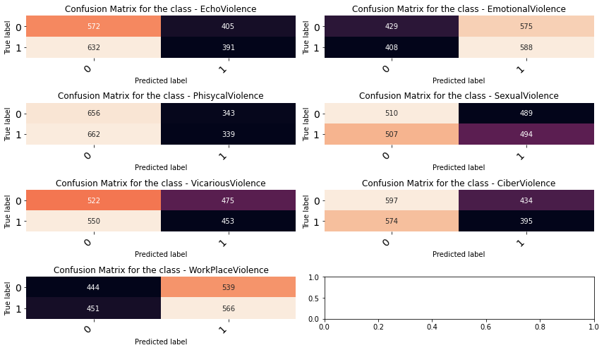

```python
fig, ax = plt.subplots(4, 2, figsize=(12, 7))

for axes, cfs_matrix, label in zip(ax.flatten(), cm, categories):
        print_confusion_matrix(cfs_matrix, axes, label, ["N", "Y"])

fig.tight_layout()
plt.show()
```

**4.0 ALGORITMOS CLASIFICACIÓN PARA EL CONJUNTO DE DATOS DE AGRESORES**

**4.1 SOPORTAN CLASIFICACIÓN MULTILABEL DE FORMA NATIVA**

**Random Forest Classifier**

```python
# Random Forest Classifier

clf=RandomForestClassifier(random_state=42)
```

```python
# Grid de parámetros

param_grid = {
    'n_estimators': [200, 500],
    'max_features': ['auto', 'sqrt', 'log2'],
    'max_depth' : [4,5,6,7,8],
    'criterion' :['gini', 'entropy']
}
```

```python
# Instanciamos el grid

grid = GridSearchCV(estimator=clf, param_grid=param_grid, cv= 10,scoring='f1_macro')
```

```python
# Entrenamos el grid
grid.fit(X_train_a, y_train_a)
```

```
GridSearchCV(cv=10, estimator=RandomForestClassifier(random_state=42),
             param_grid={'criterion': ['gini', 'entropy'],
                         'max_depth': [4, 5, 6, 7, 8],
                         'max_features': ['auto', 'sqrt', 'log2'],
                         'n_estimators': [200, 500]},
             scoring='f1_macro')
```

```python
# Obtenemos el mejor score, estimador y parámetros
print(grid.best_score_)
print(grid.best_params_)
print(grid.best_estimator_)
```

```
0.5121637107051145
{'criterion': 'gini', 'max_depth': 7, 'max_features': 'auto', 'n_estimators': 200}
RandomForestClassifier(max_depth=7, n_estimators=200, random_state=42)
```

```python
# Creamos el estimador con los parámetros obtenidos

clf1=RandomForestClassifier(random_state=42, max_features='auto', n_estimators= 200, max_depth=7, criterion='gini')
```

```python
# Hacemos el fit del estimador con los datos
clf1.fit(X_train_a,y_train_a)
```

```
RandomForestClassifier(max_depth=7, n_estimators=200, random_state=42)
```

```python
# Calculamos la predicción
y_pred = clf1.predict(X_test_a)

y_pred_train = clf1.predict(X_train_a)
```

```python
print('y_test_F1_score: ',f1_score(y_test_a, y_pred, average='macro'))
print('y_train_F1_score:',f1_score(y_train_a, y_pred_train, average='macro'))
```

```
y_test_F1_score:  0.5082400040221314
y_train_F1_score: 0.7399223138013193
```

```python
print(classification_report(y_test_a,y_pred,target_names=categories,zero_division=1))
```

```
                   precision    recall  f1-score   support

     EchoViolence       0.51      0.56      0.54      1014
EmotionalViolence       0.50      0.76      0.61      1005
 PhisycalViolence       0.48      0.46      0.47       960
   SexualViolence       0.49      0.50      0.50       966
VicariousViolence       0.49      0.33      0.40      1010
    CiberViolence       0.50      0.58      0.54      1032
WorkPlaceViolence       0.50      0.52      0.51      1032

        micro avg       0.50      0.53      0.52      7019
        macro avg       0.50      0.53      0.51      7019
     weighted avg       0.50      0.53      0.51      7019
      samples avg       0.51      0.54      0.48      7019
```

```python
# Matriz de Confusión

cm = multilabel_confusion_matrix(y_test_a,y_pred)
print(cm)
```

```
[[[450 536]
  [446 568]]

 [[245 750]
  [240 765]]

 [[558 482]
  [523 437]]

 [[536 498]
  [479 487]]

 [[641 349]
  [672 338]]

 [[379 589]
  [436 596]]

 [[438 530]
  [492 540]]]
```

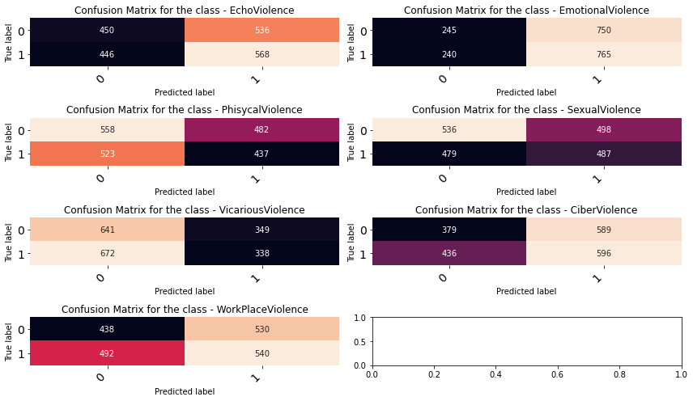

```python
fig, ax = plt.subplots(4, 2, figsize=(12, 7))

for axes, cfs_matrix, label in zip(ax.flatten(), cm, categories):
        print_confusion_matrix(cfs_matrix, axes, label, ["N", "Y"])

fig.tight_layout()
plt.show()
```

**MLP Classifier**

```python
# MLP Classifier

param_grid = [
        {
            'activation' : ['identity', 'logistic', 'tanh', 'relu'],
            'solver' : ['lbfgs', 'sgd', 'adam'],
            'hidden_layer_sizes': [
             (1,),(2,),(3,),(4,),(5,),(6,),(7,),(8,),(9,),(10,),(11,), (12,),(13,),(14,),(15,),(16,),(17,),(18,),(19,),(20,),(21,)
             ]
        }
       ]
```

```python
clf = GridSearchCV(MLPClassifier(max_iter = 300), param_grid, cv=10, scoring='f1_macro')
clf.fit(X_train_a,y_train_a)
```

```python
print(clf.best_params_)
print(clf.best_score_)
print(clf.best_estimator_)
```

```
{'activation': 'tanh', 'hidden_layer_sizes': (20,), 'solver': 'lbfgs'}
0.497121518877307
MLPClassifier(activation='tanh', hidden_layer_sizes=(20,), max_iter=300,
              solver='lbfgs')
```

```python
clf= MLPClassifier(hidden_layer_sizes=(20,), activation='tanh',
                       solver='lbfgs', alpha=0.01,learning_rate='constant',
                      learning_rate_init=0.001, max_iter = 300)



clf.fit(X_train_a,y_train_a)
```

```python
# Calculamos la predicción
y_pred = clf.predict(X_test_a)

y_pred_train = clf.predict(X_train_a)
```

```python
print('y_test_score F1: ',f1_score(y_test_a, y_pred, average='macro'))
print('y_train_score F1:',f1_score(y_train_a, y_pred_train, average='macro'))
```

```
y_test_score F1:  0.49681200456262353
y_train_score F1: 0.5709482622907524
```

```python
print(classification_report(y_test_a,y_pred,target_names=categories,zero_division = 1))
```

```
                   precision    recall  f1-score   support

     EchoViolence       0.51      0.49      0.50      1018
EmotionalViolence       0.49      0.48      0.48       969
 PhisycalViolence       0.50      0.49      0.50      1007
   SexualViolence       0.52      0.50      0.51      1015
VicariousViolence       0.51      0.48      0.49      1036
    CiberViolence       0.51      0.51      0.51      1009
WorkPlaceViolence       0.50      0.46      0.48       998

        micro avg       0.51      0.49      0.50      7052
        macro avg       0.51      0.49      0.50      7052
     weighted avg       0.51      0.49      0.50      7052
      samples avg       0.51      0.49      0.47      7052
```

```python
# Matriz de Confusión

cm = multilabel_confusion_matrix(y_test_a,y_pred)
print(cm)
```

```
[[[512 470]
  [521 497]]

 [[540 491]
  [502 467]]

 [[508 485]
  [515 492]]

 [[509 476]
  [509 506]]

 [[483 481]
  [538 498]]

 [[498 493]
  [492 517]]

 [[543 459]
  [534 464]]]
```

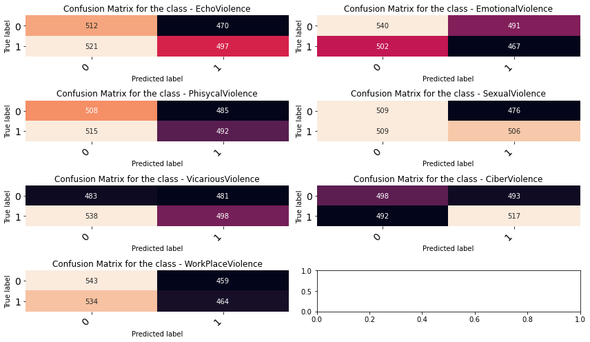

```python
fig, ax = plt.subplots(4, 2, figsize=(12, 7))

for axes, cfs_matrix, label in zip(ax.flatten(), cm, categories):
        print_confusion_matrix(cfs_matrix, axes, label, ["N", "Y"])

fig.tight_layout()
plt.show()
```

**Decision Tree Classifier**

```python
# Decision Tree
# Definimos los parámetros a buscar

max_depth = [4,5,6,7,8,9,10]
print('Valores de max_depth :',max_depth)
min_samples_split = [2,10,20,50,100]
print('Valores de min_samples_split: ',min_samples_split)
```

```
Valores de max_depth : [4, 5, 6, 7, 8, 9, 10]
Valores de min_samples_split:  [2, 10, 20, 50, 100]
```

```python
# Creamos un diccionario de parámetros

param_grid = dict(max_depth=max_depth,min_samples_split=min_samples_split)
print(param_grid)
```

```
{'max_depth': [4, 5, 6, 7, 8, 9, 10], 'min_samples_split': [2, 10, 20, 50, 100]}
```

```python
# Instanciamos el grid

grid = GridSearchCV(DecisionTreeClassifier(), param_grid, cv=10, scoring='f1_macro')
```

```python
# hacemos el fit del grid con los datos

grid_results = grid.fit(X_train_a, y_train_a)
```

```python
print(grid_results.best_score_)
print(grid_results.best_params_)
print(grid_results.best_estimator_)
```

```
0.4971087112962446
{'max_depth': 8, 'min_samples_split': 100}
DecisionTreeClassifier(max_depth=8, min_samples_split=100)
```

```python
clf = DecisionTreeClassifier(max_depth=8, min_samples_split=100)
```

```python
# Lo entrenamos
clf = clf.fit(X_train_a,y_train_a)
```

```python
# Calculamos la predicción
y_pred = clf.predict(X_test_a)

y_pred_train = clf.predict(X_train_a)
```

```python
print('y_test score F1: ',f1_score(y_test_a, y_pred, average='macro'))
print('y_train_score F1:',f1_score(y_train_a, y_pred_train, average='macro'))
```

```
y_test score F1:  0.5028619992792952
y_train_score F1: 0.5633258122667596
```

```python
print(classification_report(y_test_a,y_pred,target_names=categories,zero_division = 1))
```

```
                   precision    recall  f1-score   support

     EchoViolence       0.52      0.55      0.53      1014
EmotionalViolence       0.51      0.54      0.52      1005
 PhisycalViolence       0.48      0.43      0.46       960
   SexualViolence       0.49      0.50      0.50       966
VicariousViolence       0.50      0.42      0.46      1010
    CiberViolence       0.52      0.52      0.52      1032
WorkPlaceViolence       0.52      0.54      0.53      1032

        micro avg       0.51      0.50      0.50      7019
        macro avg       0.51      0.50      0.50      7019
     weighted avg       0.51      0.50      0.50      7019
      samples avg       0.51      0.50      0.47      7019
```

```python
# Matriz de Confusión

cm = multilabel_confusion_matrix(y_test_a,y_pred)
print(cm)
```

```
[[[481 505]
  [460 554]]

 [[471 524]
  [464 541]]

 [[602 438]
  [548 412]]

 [[539 495]
  [481 485]]

 [[576 414]
  [588 422]]

 [[463 505]
  [492 540]]

 [[449 519]
  [470 562]]]
```

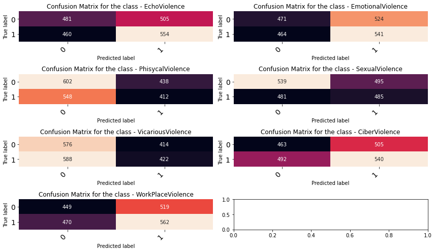

```python
fig, ax = plt.subplots(4, 2, figsize=(12, 7))

for axes, cfs_matrix, label in zip(ax.flatten(), cm, categories):
        print_confusion_matrix(cfs_matrix, axes, label, ["N", "Y"])

fig.tight_layout()
plt.show()
```

**Nearest Kneighbors Classifier**

```python
# Nearest Kneighbors Classifier

from sklearn.model_selection import GridSearchCV

knn = KNeighborsClassifier(n_neighbors=20)

k_range = list(range(1, 10))

weight_options = ['uniform', 'distance']

param_grid = dict(n_neighbors=k_range, weights=weight_options)

print(param_grid)

grid = GridSearchCV(KNeighborsClassifier(), param_grid, cv=10, scoring='f1_macro')
```

```
{'n_neighbors': [1, 2, 3, 4, 5, 6, 7, 8, 9], 'weights': ['uniform', 'distance']}
```

```python
# Hacemos el fit del grid con los datos

grid.fit(X_train_a,y_train_a)
```

```
GridSearchCV(cv=10, estimator=KNeighborsClassifier(),
             param_grid={'n_neighbors': [1, 2, 3, 4, 5, 6, 7, 8, 9],
                         'weights': ['uniform', 'distance']},
             scoring='f1_macro')
```

```python
print(grid.best_score_)
print(grid.best_params_)
print(grid.best_estimator_)
```

```
0.506893723981417
{'n_neighbors': 5, 'weights': 'uniform'}
KNeighborsClassifier()
```

```python
clf = KNeighborsClassifier(n_neighbors=5,weights='uniform')
```

```python
# Lo entrenamos
clf = clf.fit(X_train_a,y_train_a)
```

```python
# Calculamos la predicción
y_pred = clf.predict(X_test_a)

y_pred_train = clf.predict(X_train_a)
```

```python
print('y_test_score F1: ',f1_score(y_test_a, y_pred, average='macro'))
print('y_train_score F1:',f1_score(y_train_a, y_pred_train, average='macro'))
```

```
y_test_score F1:  0.4972217230592729
y_train_score F1: 0.6915220580794939
```

```python
print(classification_report(y_test_a,y_pred,target_names=categories,zero_division = 1))
```

```
                   precision    recall  f1-score   support

     EchoViolence       0.49      0.49      0.49      1014
EmotionalViolence       0.51      0.54      0.52      1005
 PhisycalViolence       0.48      0.51      0.49       960
   SexualViolence       0.47      0.48      0.48       966
VicariousViolence       0.51      0.47      0.49      1010
    CiberViolence       0.51      0.51      0.51      1032
WorkPlaceViolence       0.51      0.48      0.50      1032

        micro avg       0.50      0.50      0.50      7019
        macro avg       0.50      0.50      0.50      7019
     weighted avg       0.50      0.50      0.50      7019
      samples avg       0.50      0.50      0.46      7019
```

```python
# Matriz de Confusión

cm = multilabel_confusion_matrix(y_test_a,y_pred)
print(cm)
```

```
[[[461 525]
  [516 498]]

 [[470 525]
  [462 543]]

 [[510 530]
  [472 488]]

 [[508 526]
  [500 466]]

 [[532 458]
  [533 477]]

 [[456 512]
  [501 531]]

 [[496 472]
  [536 496]]]
```

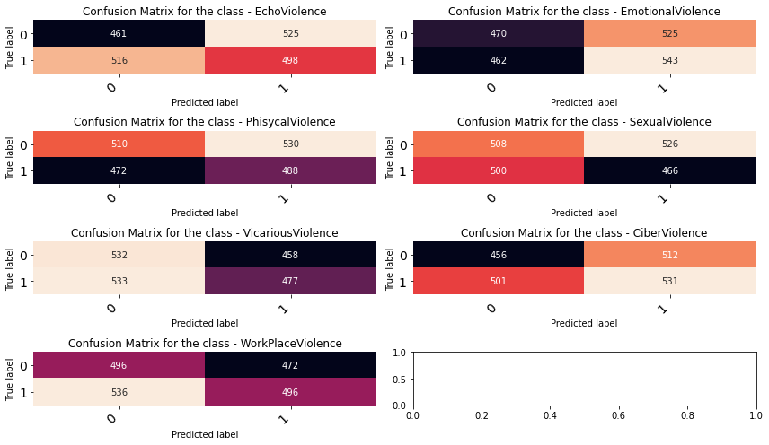

```python
fig, ax = plt.subplots(4, 2, figsize=(12, 7))

for axes, cfs_matrix, label in zip(ax.flatten(), cm, categories):
        print_confusion_matrix(cfs_matrix, axes, label, ["N", "Y"])

fig.tight_layout()
plt.show()
```

```python
# Binary Relevance


from skmultilearn.problem_transform import BinaryRelevance
from sklearn.naive_bayes import GaussianNB

# inincializamos con un clasificador base
classifier = BinaryRelevance(GaussianNB())
# train
classifier.fit(X_train_a, y_train_a)
# predict
predictions = classifier.predict(X_test_a)

print("F1_score = ",f1_score(y_test_a,predictions,average='macro'))
```

```
F1_score =  0.5078369600574156
```

```python
print(classification_report(y_test_a,predictions,target_names=categories,zero_division = 1))
```

```
                   precision    recall  f1-score   support

     EchoViolence       0.52      0.53      0.53      1014
EmotionalViolence       0.49      0.62      0.55      1005
 PhisycalViolence       0.50      0.48      0.49       960
   SexualViolence       0.49      0.49      0.49       966
VicariousViolence       0.52      0.43      0.47      1010
    CiberViolence       0.51      0.53      0.52      1032
WorkPlaceViolence       0.51      0.52      0.51      1032

        micro avg       0.50      0.51      0.51      7019
        macro avg       0.51      0.51      0.51      7019
     weighted avg       0.51      0.51      0.51      7019
      samples avg       0.50      0.51      0.47      7019
```

```python
# Matriz de Confusión

cm = multilabel_confusion_matrix(y_test_a,predictions)
print(cm)
```

```
[[[481 505]
  [472 542]]

 [[340 655]
  [382 623]]

 [[588 452]
  [500 460]]

 [[540 494]
  [493 473]]

 [[590 400]
  [580 430]]

 [[438 530]
  [483 549]]

 [[465 503]
  [500 532]]]
```

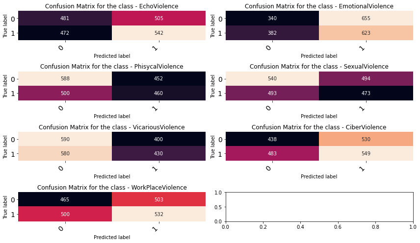

```python
fig, ax = plt.subplots(4, 2, figsize=(12, 7))

for axes, cfs_matrix, label in zip(ax.flatten(), cm, categories):
        print_confusion_matrix(cfs_matrix, axes, label, ["N", "Y"])

fig.tight_layout()
plt.show()
```

```python
# classifier chains

from skmultilearn.problem_transform import ClassifierChain
from sklearn.linear_model import LogisticRegression

# inicializamos con un clasificador base LogisticRegression
classifier = ClassifierChain(LogisticRegression())
# train
classifier.fit(X_train_a, y_train_a)
# predicción
predictions = classifier.predict(X_test_a)

print("F1_score = ",f1_score(y_test_a,predictions,average='macro'))
```

```
F1_score =  0.5051473029580399
```

```python
print(classification_report(y_test_a,predictions,target_names=categories,zero_division = 1))
```

```
                   precision    recall  f1-score   support

     EchoViolence       0.52      0.54      0.53      1014
EmotionalViolence       0.49      0.62      0.55      1005
 PhisycalViolence       0.51      0.50      0.50       960
   SexualViolence       0.49      0.49      0.49       966
VicariousViolence       0.51      0.42      0.46      1010
    CiberViolence       0.52      0.51      0.52      1032
WorkPlaceViolence       0.50      0.48      0.49      1032

        micro avg       0.51      0.51      0.51      7019
        macro avg       0.51      0.51      0.51      7019
     weighted avg       0.51      0.51      0.51      7019
      samples avg       0.51      0.51      0.46      7019
```

```python
# Matriz de Confusión

cm = multilabel_confusion_matrix(y_test_a,predictions)
print(cm)
```

```
[[[492 494]
  [471 543]]

 [[350 645]
  [384 621]]

 [[580 460]
  [483 477]]

 [[530 504]
  [488 478]]

 [[594 396]
  [590 420]]

 [[475 493]
  [503 529]]

 [[472 496]
  [535 497]]]
```

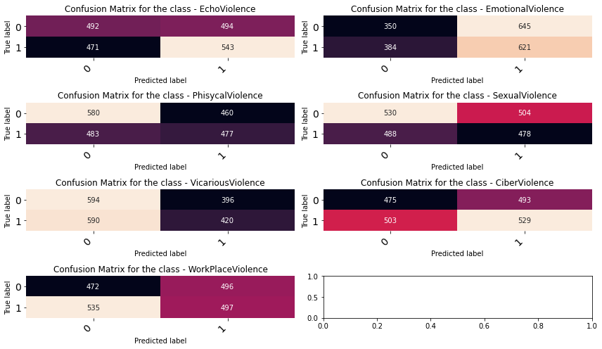

```python
fig, ax = plt.subplots(4, 2, figsize=(12, 7))

for axes, cfs_matrix, label in zip(ax.flatten(), cm, categories):
        print_confusion_matrix(cfs_matrix, axes, label, ["N", "Y"])

fig.tight_layout()
plt.show()
```

```python
# Label Powerset

from skmultilearn.problem_transform import LabelPowerset
# initialize label powerset multi-label classifier
classifier = LabelPowerset(LogisticRegression())
# train
classifier.fit(X_train_a, y_train_a)
# predicción
predictions = classifier.predict(X_test_a)
print("F1_score = ",f1_score(y_test_a,predictions,average='macro'))
```

```
F1_score =  0.49595107818951056
```

```python
print(classification_report(y_test_a,predictions,target_names=categories,zero_division = 1))
```

```
                   precision    recall  f1-score   support

     EchoViolence       0.51      0.47      0.49      1014
EmotionalViolence       0.51      0.43      0.47      1005
 PhisycalViolence       0.52      0.47      0.49       960
   SexualViolence       0.47      0.50      0.49       966
VicariousViolence       0.52      0.48      0.50      1010
    CiberViolence       0.51      0.50      0.51      1032
WorkPlaceViolence       0.52      0.56      0.54      1032

        micro avg       0.51      0.49      0.50      7019
        macro avg       0.51      0.49      0.50      7019
     weighted avg       0.51      0.49      0.50      7019
      samples avg       0.51      0.49      0.46      7019
```

```python
# Matriz de Confusión

cm = multilabel_confusion_matrix(y_test_a,predictions)
print(cm)
```

```
[[[516 470]
  [533 481]]

 [[567 428]
  [568 437]]

 [[619 421]
  [511 449]]

 [[479 555]
  [479 487]]

 [[544 446]
  [530 480]]

 [[473 495]
  [515 517]]

 [[437 531]
  [458 574]]]
```

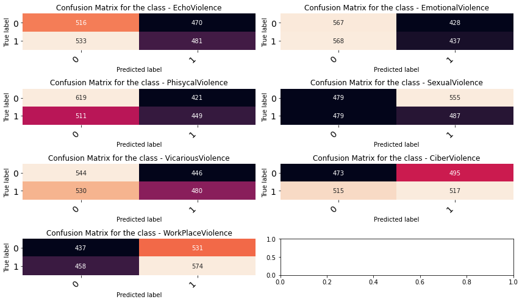

```python
fig, ax = plt.subplots(4, 2, figsize=(12, 7))

for axes, cfs_matrix, label in zip(ax.flatten(), cm, categories):
        print_confusion_matrix(cfs_matrix, axes, label, ["N", "Y"])

fig.tight_layout()
plt.show()
```

**4.3 MULTIOUTPUT CLASSIFIER (Algoritmos que no soportan multilabel de forma nativa)**

Esta estrategia consiste en utilizar un clasificador por objetivo (label). Se trata de una estrategia simple para ampliar los clasificadores que no admiten de forma nativa la clasificación multilabel.

```python
from sklearn import model_selection
from sklearn.svm import LinearSVC

# preparación de modelos y configuración

seed = 7
models = []
models.append(('XGB', XGBClassifier(objective='binary:logistic',eval_metric='error')))
models.append(('LR', LogisticRegression()))
models.append(('NB', GaussianNB()))
models.append(('SVM', LinearSVC()))

# evaluación de modelos

results = []
names = []
scoring = 'f1_macro'
for name, model in models:
    kfold = model_selection.KFold(n_splits=5, random_state=seed, shuffle=True)
    cv_results = model_selection.cross_val_score(MultiOutputClassifier(model), X_train_a, y_train_a.to_numpy(), cv=kfold, scoring=scoring)
    results.append(cv_results)
    names.append(name)
    msg = "%s: %f (%f)" % (name, cv_results.mean(), cv_results.std())
    print(msg)
```

```
XGB: 0.503610 (0.004299)
LR: 0.509272 (0.003729)
NB: 0.508369 (0.002055)
```

```
SVM: 0.509318 (0.003682)
```

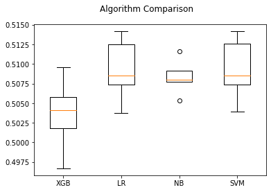

```python
# comparación de algoritmos mediante boxplot

fig = plt.figure()
fig.suptitle('Algorithm Comparison')
ax = fig.add_subplot(111)
plt.boxplot(results)
ax.set_xticklabels(names)
plt.show()
```

**4.4 MULTILEARN ADAPT APPROACHES**